# IODS course project

yufanyin

# Chapter 1 Start up

**Introduction Warmup**

It is a good beginning. The task in DataCamp is friendly to beginners.

Clustering and classification, and dimensionality reduction techniques are the two parts I am most interested in.

I heard this course via email sent to HYMY students.

The link to my github repository:

https://github.com/yufanyin/IODS-project

The link to my course diary:

https://yufanyin.github.io/IODS-project/

**work through the DataCamp:**

DataCamp 1 Hello R

DataCamp 2 Getting Hooked on R

# Chapter 2 Regression and model validation

(5.11.-11.11.2019)

- **Work through the DataCamp**

  DataCamp 3 Regression and model validation
- **Data wrangling**

  R script of data Wrangling exercise is available here.

  https://github.com/yufanyin/IODS-project/blob/master/create_learning2014.R

  The result was saved as ‘learning2014.csv’.

**Note:** ‘(Step N)’ is used for reviewers to check my work queicky.

## 2.1 Reading the data

Read the data file (Step 1a)

```r
learning2014 <-
read.table(file = "G:/C-Open Data Science/0-191030/IODS-project-master/learning2014.txt", stringsAsFactors = TRUE)
str(learning2014)
```

```
## 'data.frame':    166 obs. of  7 variables:
##  $ gender  : Factor w/ 2 levels "F","M": 1 2 1 2 2 1 2 1 2 1 ...
##  $ age     : int  53 55 49 53 49 38 50 37 37 42 ...
##  $ attitude: num  3.7 3.1 2.5 3.5 3.7 3.8 3.5 2.9 3.8 2.1 ...
##  $ deep    : num  3.58 2.92 3.5 3.5 3.67 ...
##  $ stra    : num  3.38 2.75 3.62 3.12 3.62 ...
##  $ surf    : num  2.58 3.17 2.25 2.25 2.83 ...
##  $ points  : int  25 12 24 10 22 21 21 31 24 26 ...
```

Describe the dataset briefly (Step 1b)

The data ‘learning2014’ consists of 166 observations and 7 variables. It contains students’ approaches to learning (deep, stra, surf), scores of attitude, points and some background information (gender, age).

## 2.2 Visualizations with ggplot2

(Step 2)

Correlations of the observations between the different variables are shown below with `ggpairs()` function.

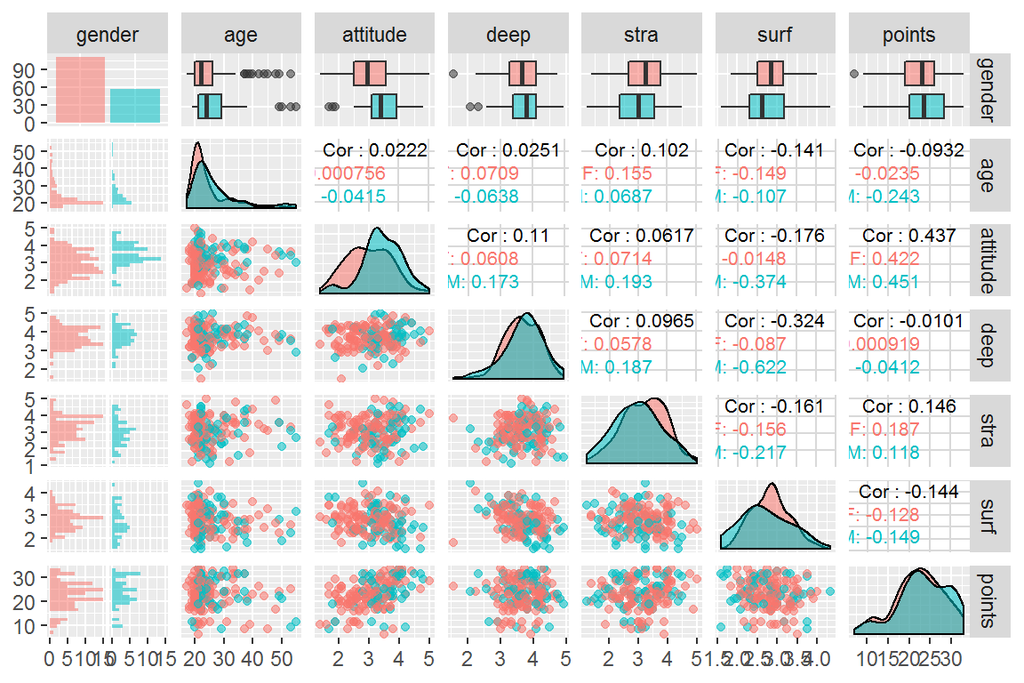

```r
library(ggplot2)
library(GGally)
p1 <- ggpairs(learning2014, mapping = aes(col = gender, alpha = 0.3), lower = list(combo = wrap("facethist", bins = 20)), upper = list(continuous = wrap("cor", size = 2.8)))
p1
```

The plot shows the data distribution of all the 166 observations of each variable. The colours represent different gender. Female students are shown in red and male students in verdant. In the upper right part presents how one variable correlates to another varibable. We are able to find possible significant regression result.

## 2.3 Simple regression with lm()

(Step 3)

**Simple regression: point ~ gender** Firstly we choose gender as explanatory variables and fit a regression model in which exam points is the dependent variable. Result: not significant.

```r
gender_lm <- lm(points ~ gender, data = learning2014)
summary(gender_lm)
```

```
##
## Call:
## lm(formula = points ~ gender, data = learning2014)
##
## Residuals:
##      Min       1Q   Median       3Q      Max
## -15.3273  -3.3273   0.5179   4.5179  10.6727
##
## Coefficients:
##             Estimate Std. Error t value Pr(>|t|)
## (Intercept)  22.3273     0.5613  39.776   <2e-16 ***
## genderM       1.1549     0.9664   1.195    0.234
## ---
## Signif. codes:  0 '***' 0.001 '**' 0.01 '*' 0.05 '.' 0.1 ' ' 1
##
## Residual standard error: 5.887 on 164 degrees of freedom
## Multiple R-squared:  0.008632,   Adjusted R-squared:  0.002587
## F-statistic: 1.428 on 1 and 164 DF,  p-value: 0.2338
```

**Simple regression: point ~ attitude**

```r
gender_lm <- lm(points ~ attitude, data = learning2014)
summary(gender_lm)
```

```
##
## Call:
## lm(formula = points ~ attitude, data = learning2014)
##
## Residuals:
##      Min       1Q   Median       3Q      Max
## -16.9763  -3.2119   0.4339   4.1534  10.6645
##
## Coefficients:
##             Estimate Std. Error t value Pr(>|t|)
## (Intercept)  11.6372     1.8303   6.358 1.95e-09 ***
## attitude      3.5255     0.5674   6.214 4.12e-09 ***
## ---
## Signif. codes:  0 '***' 0.001 '**' 0.01 '*' 0.05 '.' 0.1 ' ' 1
##
## Residual standard error: 5.32 on 164 degrees of freedom
## Multiple R-squared:  0.1906, Adjusted R-squared:  0.1856
## F-statistic: 38.61 on 1 and 164 DF,  p-value: 4.119e-09
```

There is a statistical relationship between point and attitude (p:4.12e-09). Then draw a scatter plot of points versus attitude, fit a linear model and print out the summary.

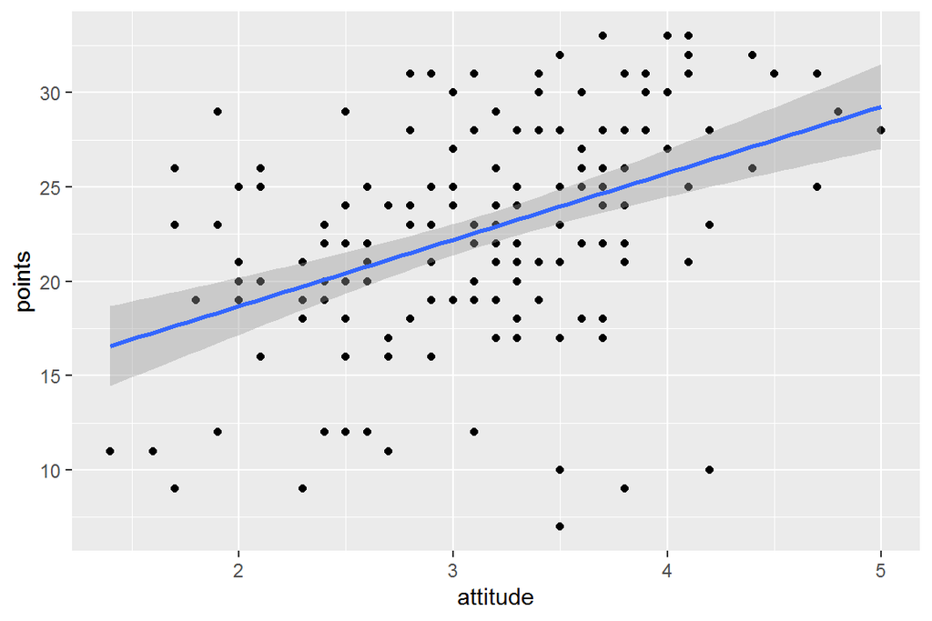

```r
qplot(attitude, points, data = learning2014) + geom_smooth(method = "lm")
```

```r
model_point_attitude <- lm(points ~ attitude, data = learning2014)
model_point_attitude
```

```
##
## Call:
## lm(formula = points ~ attitude, data = learning2014)
##
## Coefficients:
## (Intercept)     attitude
##      11.637        3.525
```

## 2.4 Multiple regression

(Step 4)

**Multiple regression model: point ~ attitude + stra** This multiple regression is to test whether strategic learning has an influence on points. The p-value (0.08) shows that the significance of the influence is not very strong. The multiple R-squared is a bit higher than that in regression model of points ~ attitude. That means a little higher correlations if strategic learning is taken into account.

```r
model_p_att_stra <- lm(points ~ attitude + stra, data = learning2014)
model_p_att_stra_s <- summary(model_p_att_stra)
model_p_att_stra_s
```

```
##
## Call:
## lm(formula = points ~ attitude + stra, data = learning2014)
##
## Residuals:
##      Min       1Q   Median       3Q      Max
## -17.6436  -3.3113   0.5575   3.7928  10.9295
##
## Coefficients:
##             Estimate Std. Error t value Pr(>|t|)
## (Intercept)   8.9729     2.3959   3.745  0.00025 ***
## attitude      3.4658     0.5652   6.132 6.31e-09 ***
## stra          0.9137     0.5345   1.709  0.08927 .
## ---
## Signif. codes:  0 '***' 0.001 '**' 0.01 '*' 0.05 '.' 0.1 ' ' 1
##
## Residual standard error: 5.289 on 163 degrees of freedom
## Multiple R-squared:  0.2048, Adjusted R-squared:  0.1951
## F-statistic: 20.99 on 2 and 163 DF,  p-value: 7.734e-09
```

## 2.5 Diagnostic plots

(Step 5)

The results of diagnostic plots are in accordance with the regression model.

The residuals is close to the 0 line, which means that the relationship is linear. Not many outliers (35, 56,145) are significantly disturbing the analysis but they raise errors in the dataset.

According to Nomal Q-Q plot, most of the values fall on the straight line. The outliers cause randomness in the dataset.

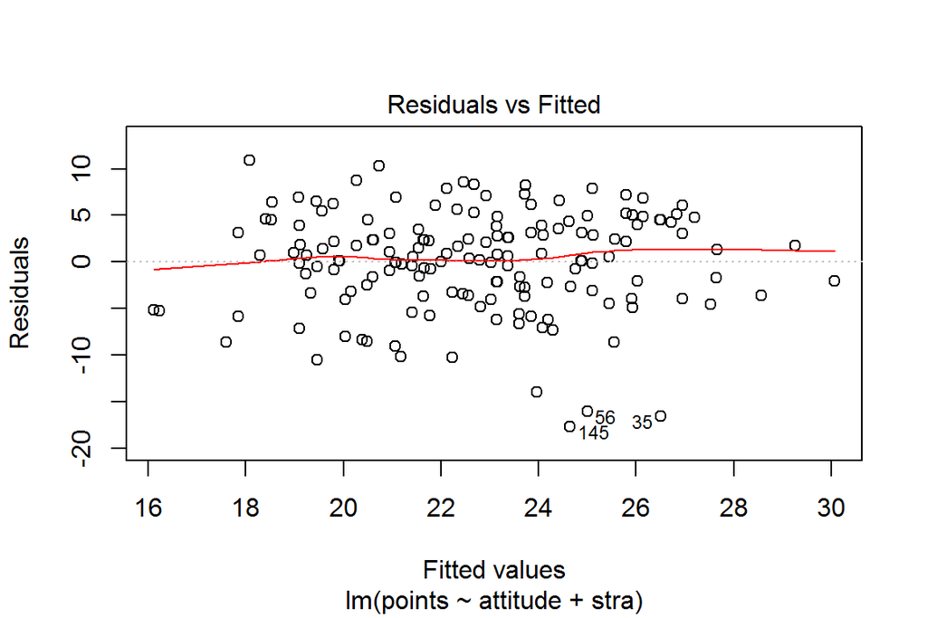

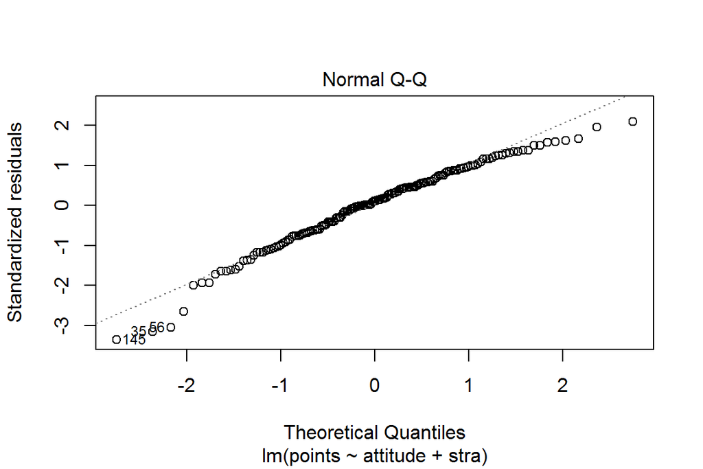

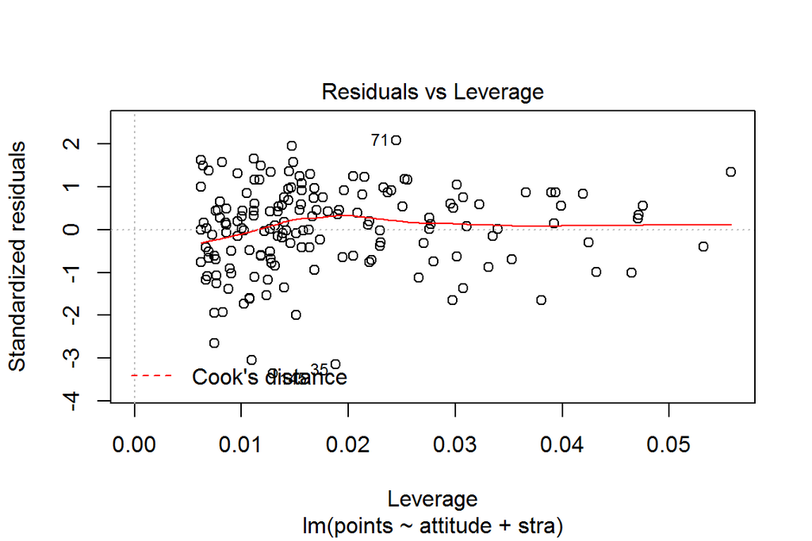

```r
plot(model_p_att_stra, which=c(1,2,5))
```

# Chapter 3 Logistic regression

(12.11.-18.11.2019)

- **Work through the DataCamp**

  DataCamp 4 Logistic regression
- **Data wrangling**

  R script of data Wrangling exercise is available here.

  https://github.com/yufanyin/IODS-project/blob/master/create_alc.R

  The result was saved as ‘alc.csv’.

**Note:** ‘(Step N)’ is used for reviewers to check my work queicky.

## 3.1 Reading the data

**Read the data file (Step 2a)**

```r
getwd()
```

```
## [1] "G:/C-Open Data Science/0-191030/IODS-project-master"
```

```r
setwd("G:/C-Open Data Science/0-191030/IODS-project-master")
alc <- read.csv(file = "G:/C-Open Data Science/0-191030/IODS-project-master/alc.csv")
```

**Print out the names of the variables in the data (Step 2b)**

```r
dim(alc)
```

```
## [1] 382  36
```

```r
colnames(alc)
```

```
##  [1] "X"          "school"     "sex"        "age"        "address"
##  [6] "famsize"    "Pstatus"    "Medu"       "Fedu"       "Mjob"
## [11] "Fjob"       "reason"     "nursery"    "internet"   "guardian"
## [16] "traveltime" "studytime"  "failures"   "schoolsup"  "famsup"
## [21] "paid"       "activities" "higher"     "romantic"   "famrel"
## [26] "freetime"   "goout"      "Dalc"       "Walc"       "health"
## [31] "absences"   "G1"         "G2"         "G3"         "alc_use"
## [36] "high_use"
```

```r
str(alc)
```

```
## 'data.frame':    382 obs. of  36 variables:
##  $ X         : int  1 2 3 4 5 6 7 8 9 10 ...
##  $ school    : Factor w/ 2 levels "GP","MS": 1 1 1 1 1 1 1 1 1 1 ...
##  $ sex       : Factor w/ 2 levels "F","M": 1 1 1 1 1 2 2 1 2 2 ...
##  $ age       : int  18 17 15 15 16 16 16 17 15 15 ...
##  $ address   : Factor w/ 2 levels "R","U": 2 2 2 2 2 2 2 2 2 2 ...
##  $ famsize   : Factor w/ 2 levels "GT3","LE3": 1 1 2 1 1 2 2 1 2 1 ...
##  $ Pstatus   : Factor w/ 2 levels "A","T": 1 2 2 2 2 2 2 1 1 2 ...
##  $ Medu      : int  4 1 1 4 3 4 2 4 3 3 ...
##  $ Fedu      : int  4 1 1 2 3 3 2 4 2 4 ...
##  $ Mjob      : Factor w/ 5 levels "at_home","health",..: 1 1 1 2 3 4 3 3 4 3 ...
##  $ Fjob      : Factor w/ 5 levels "at_home","health",..: 5 3 3 4 3 3 3 5 3 3 ...
##  $ reason    : Factor w/ 4 levels "course","home",..: 1 1 3 2 2 4 2 2 2 2 ...
##  $ nursery   : Factor w/ 2 levels "no","yes": 2 1 2 2 2 2 2 2 2 2 ...
##  $ internet  : Factor w/ 2 levels "no","yes": 1 2 2 2 1 2 2 1 2 2 ...
```

[output cut: 22 more lines]

**Describe the data set briefly (Step 2c)**

**Note:** It shows 36 variables. Why the first colname is “X” (int 1 2 3 4 5 6 7 8 9 10 …)?

The data were collected by using school reports and questionnaires from students in two Portugal secondary schools. They included students’ grades, demographic characteristics, social and school related features.

The two data sets provided students’ performance in Mathematics (mat) and Portuguese language (por). After data wrangling part, they were merged into one data set “alc”.

To analyse alcohol consumption, two new variables were created. “alc_use” is the average of weekday (“Dalc”) and weekend (“Walc”) alcohol consumption. “high_use” is the logical value created if the “alc_use” of a student is higher than 2 (TRUE).

Data source: https://archive.ics.uci.edu/ml/datasets/Student+Performance

## 3.2 Hypotheses about the relationships between alcohol consumption and specific variables

**Choose variables and write hypotheses (Step 3)**

The purpose of the following analysis is to explore the relationships between high/low alcohol consumption and some variables. I chose the following four variables:

‘sex’: student’s sex (binary: ‘F’ - female or ‘M’ - male)

‘failures’: number of past class failures (numeric: n if 1<=n<3, else 4)

‘goout’: going out with friends (numeric: from 1 - very low to 5 - very high)

‘absences’: number of school absences (numeric: from 0 to 93)

The hypotheses are as follows.

**Hypothesis 1:** There is gender difference (‘sex’) in alcohol consumption. In social science, gender affect many behaviors and preferences and becomes a variable being tested often.

**Hypothesis 2:** The number of class failures (‘failures’) associates with alcohol consumption. Students with more class failures have higher alcohol consumption.

**Hypothesis 3:** The frequency of going out with friends (‘goout’) associates with alcohol consumption. Students going out with friends more often have higher alcohol consumption.

**Hypothesis 4:** The number of school absences (‘absences’) associates with alcohol consumption. Students having more times of school absences have higher alcohol consumption.

## 3.3 Exploring the relationships numerically and graphically

**(Step 4)**

```r
library(tidyr)
library(dplyr)
library(ggplot2)
library(knitr)
library(kableExtra)
```

### 3.3.1 Alcohol consumption and gender

```r
alc %>% group_by(sex) %>% summarise(count = n()) -> fm
knitr::kable(fm, caption="Students' gender distribution") %>% kable_styling(bootstrap_options = "hover", full_width = FALSE, position = "center")
```

Students’ gender distribution

| sex | count |
| --- | --- |
| F | 198 |
| M | 184 |

There were 198 female students and 184 male students.

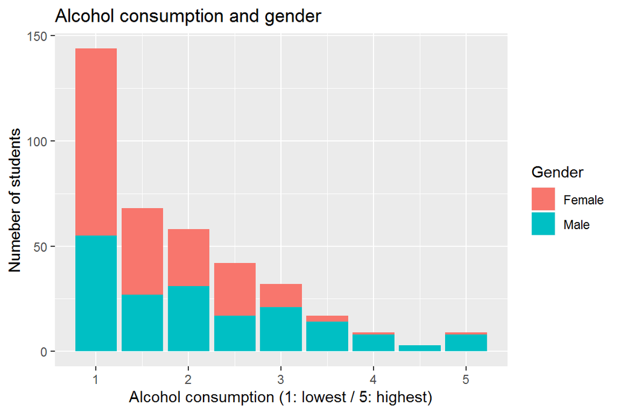

```r
ggplot(data = alc, aes(x = alc_use, fill = sex)) + geom_bar() + xlab("Alcohol consumption (1: lowest / 5: highest)") + ylab("Numeber of students") + ggtitle("Alcohol consumption and gender") + scale_fill_discrete("Gender", labels = c("Female", "Male"))
```

Te figure presents the distribution of alcohol consumption taking gender into account. 1 means the lowest consumption, 5 is the highest consumption.

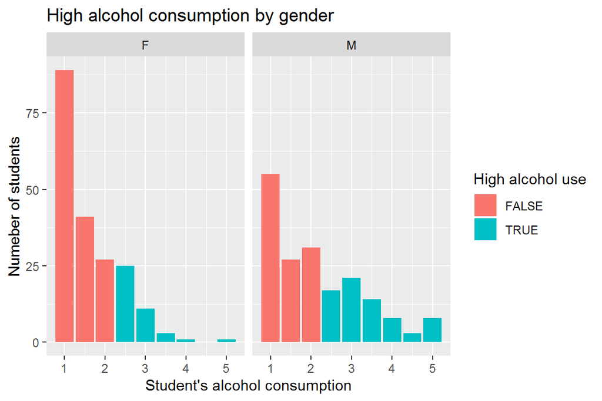

```r
ggplot(data = alc, aes(x = alc_use, fill = high_use)) + facet_wrap("sex") + geom_bar() + xlab("Student's alcohol consumption") + ggtitle("High alcohol consumption by gender") + ylab("Numeber of students") + scale_fill_discrete("High alcohol use")
```

### 3.3.2 Alcohol consumption and number of class failures

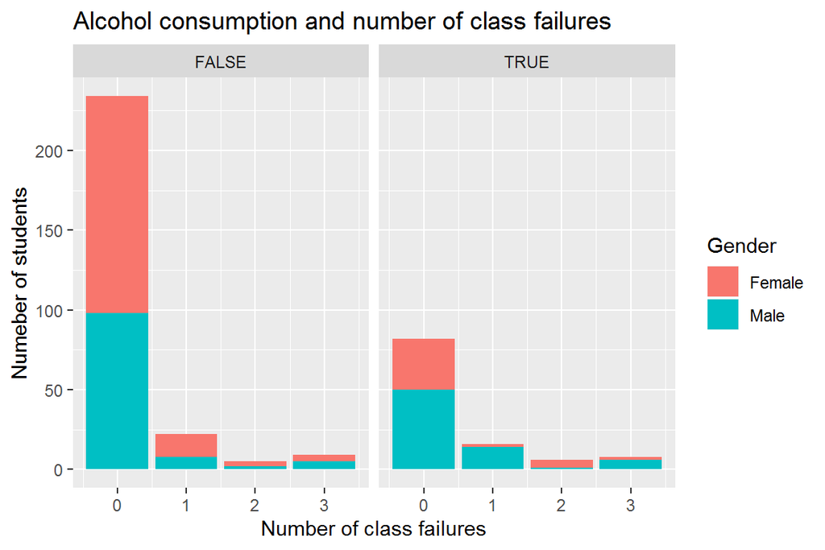

```r
ggplot(data = alc, aes(x = failures,  fill = sex)) + geom_bar() + facet_wrap("high_use") + ggtitle("Alcohol consumption and number of class failures") + xlab("Number of class failures") + ylab("Numeber of students") + scale_fill_discrete("Gender", labels = c("Female", "Male"))
```

### 3.3.3 Alcohol consumption and frequency of going out with friends

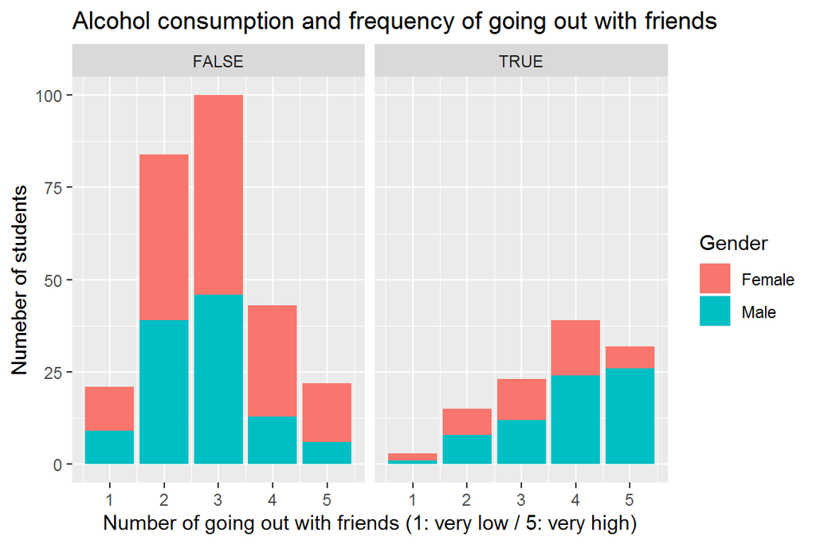

```r
ggplot(data = alc, aes(x = goout,  fill = sex)) + geom_bar() + facet_wrap("high_use") + ggtitle("Alcohol consumption and frequency of going out with friends") + xlab("Number of going out with friends (1: very low / 5: very high)") + ylab("Numeber of students") + scale_fill_discrete("Gender", labels = c("Female", "Male"))
```

### 3.3.4 Alcohol consumption and number of school absences

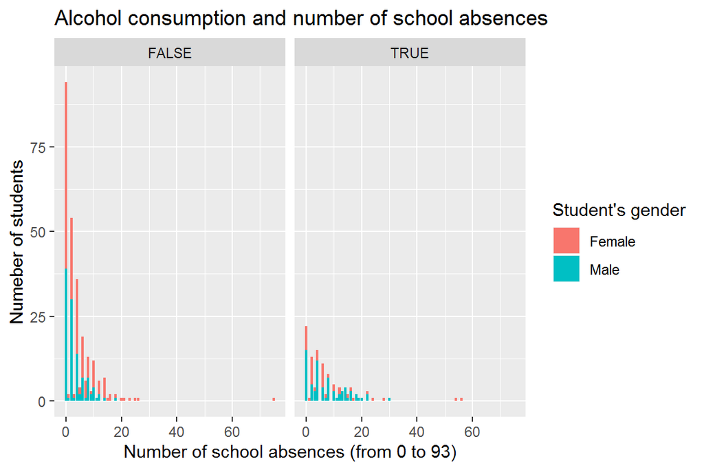

```r
ggplot(data = alc, aes(x = absences,  fill = sex)) + geom_bar() + facet_wrap("high_use") + ggtitle("Alcohol consumption and number of school absences") + xlab("Number of school absences (from 0 to 93)") + ylab("Numeber of students") + scale_fill_discrete("Student's gender", labels = c("Female", "Male"))
```

## 3.4 Exploring the relationship using logistic regression

### 3.4.1 The fitted model

**(Step 5a)**

‘sex’, ‘failures’,‘goout’ and ‘absences’

```r
lr_glm <- glm(high_use ~ sex + failures + goout + absences, data = alc, family = "binomial")
lr_glm_sum <- summary(lr_glm)
```

### 3.4.2 The coefficients of the model

**(Step 5b)**

```r
lr_glm_sum
```

```
##
## Call:
## glm(formula = high_use ~ sex + failures + goout + absences, family = "binomial",
##     data = alc)
##
## Deviance Residuals:
##     Min       1Q   Median       3Q      Max
## -1.8046  -0.7661  -0.5196   0.7383   2.3862
##
## Coefficients:
##             Estimate Std. Error z value Pr(>|z|)
## (Intercept) -4.21840    0.47865  -8.813  < 2e-16 ***
## sexM         0.97670    0.25898   3.771 0.000162 ***
## failures     0.28657    0.17170   1.669 0.095111 .
## goout        0.71559    0.12089   5.919 3.24e-09 ***
## absences     0.06550    0.01685   3.888 0.000101 ***
## ---
## Signif. codes:  0 '***' 0.001 '**' 0.01 '*' 0.05 '.' 0.1 ' ' 1
##
## (Dispersion parameter for binomial family taken to be 1)
##
##     Null deviance: 462.21  on 381  degrees of freedom
## Residual deviance: 378.67  on 377  degrees of freedom
## AIC: 388.67
##
## Number of Fisher Scoring iterations: 4
```

```r
knitr::kable(lr_glm_sum$coefficients, digits = 3, align = "l", justify = "left", caption="Model coefficients of choosen variables") %>% kable_styling(bootstrap_options = "striped", full_width = F, position = "center")
```

Model coefficients of choosen variables

|  | Estimate | Std. Error | z value | Pr(>\|z\|) |
| --- | --- | --- | --- | --- |
| (Intercept) | -4.218 | 0.479 | -8.813 | 0.000 |
| sexM | 0.977 | 0.259 | 3.771 | 0.000 |
| failures | 0.287 | 0.172 | 1.669 | 0.095 |
| goout | 0.716 | 0.121 | 5.919 | 0.000 |
| absences | 0.066 | 0.017 | 3.888 | 0.000 |

**The output shows**

- Being a male student instead of a female student significantly (p < 0.001) increased the probability of high alcohol consumption.
- Class failure had a positive effect on high consumption with a smaller probability (p = 0.095).
- The frenquency of going out with friends had a significant positive effect on high alcohol consumption (p < 0.001).
- School absences had a significant positive effect on high alcohol consumption (< 0.001).

### 3.4.3 The odds ratios and confidence intervals

**(Step 5c)**

Odds ratios

```r
or_lr <- coef(lr_glm) %>% exp
or_lr
```

```
## (Intercept)        sexM    failures       goout    absences
##  0.01472214  2.65567230  1.33184898  2.04538456  1.06769512
```

Confidence intervals

```r
ci_lr <- confint(lr_glm) %>% exp
ci_lr
```

```
##                   2.5 %     97.5 %
## (Intercept) 0.005520616 0.03620626
## sexM        1.608518976 4.45004345
## failures    0.949933462 1.86808335
## goout       1.623552039 2.61096941
## absences    1.035225148 1.10698949
```

Print out the odds ratios with their confidence intervals

```r
od_conf <- cbind(or_lr, ci_lr)
colnames(od_conf) <- c("odds ratios","2.5 %", "97.5 %")
knitr::kable(od_conf, digits = 3, align = "l",  caption="Odds ratios and confidental intervals") %>% kable_styling(bootstrap_options = "striped", full_width = F, position = "center")
```

Odds ratios and confidental intervals

|  | odds ratios | 2.5 % | 97.5 % |
| --- | --- | --- | --- |
| (Intercept) | 0.015 | 0.006 | 0.036 |
| sexM | 2.656 | 1.609 | 4.450 |
| failures | 1.332 | 0.950 | 1.868 |
| goout | 2.045 | 1.624 | 2.611 |
| absences | 1.068 | 1.035 | 1.107 |

## 3.5 The predictive power of you model

**(Step 6)**

```r
probs <- predict(lr_glm, type = "response")
alc <- mutate(alc, prob = probs)
alc <- mutate(alc, pred = prob > 0.5)
select(alc, age, failures, goout, absences, high_use, prob, pred) %>% tail(20)
```

```
##     age failures goout absences high_use       prob  pred
## 363  17        0     3        8    FALSE 0.17542917 FALSE
## 364  17        0     5       14    FALSE 0.56870202  TRUE
## 365  18        0     4        0    FALSE 0.20488145 FALSE
## 366  18        0     2        2    FALSE 0.06560625 FALSE
## 367  18        0     3        4     TRUE 0.14068205 FALSE
## 368  18        0     3        0    FALSE 0.11188342 FALSE
## 369  17        0     4       17     TRUE 0.43966501 FALSE
## 370  18        0     4        4     TRUE 0.47069539 FALSE
## 371  18        0     3        5    FALSE 0.31703390 FALSE
## 372  17        0     3        2    FALSE 0.27608939 FALSE
## 373  19        1     2        0    FALSE 0.17887835 FALSE
## 374  18        1     3       14     TRUE 0.52713626  TRUE
## 375  18        0     3        2    FALSE 0.12557744 FALSE
## 376  18        0     3        7    FALSE 0.16615452 FALSE
## 377  19        1     2        0    FALSE 0.07581170 FALSE
## 378  18        0     4        0    FALSE 0.20488145 FALSE
## 379  18        1     1        0    FALSE 0.03855880 FALSE
## 380  18        1     1        0    FALSE 0.03855880 FALSE
## 381  17        0     5        3     TRUE 0.63011977  TRUE
## 382  18        0     1        0     TRUE 0.07404728 FALSE
```

```r
pred22 <- table(high_use = alc$high_use, pred = alc$pred)
knitr::kable(pred22, align = "l",  caption="2 x 2 cross tabulation" ) %>% kable_styling(bootstrap_options = "striped", full_width = F, position = "center") %>% add_header_above(c(" " = 1, "Pred" = 2)) %>%  pack_rows("High use", 1, 2)
```

2 x 2 cross tabulation

|  | Pred FALSE | Pred TRUE |
| --- | --- | --- |
| **High use** |  |  |
| FALSE | 251 | 19 |
| TRUE | 62 | 50 |

The model reported 251 correct false results and 62 false negative results. Among the 62 cases, students had high alcohol consumption but the model predicted not. Among the 19 false positive prediction cases, the model predicted high alcohol consumption but it was not in fact.

```r
loss_func <- function(class, prob) {
  n_wrong <- abs(class - prob) > 0.5
  mean(n_wrong)
}
loss_func(class = alc$high_use, prob = alc$prob)
```

```
## [1] 0.2120419
```

It showed that 21.2% of all predictions was incorrect.

## 3.6 The 10-fold cross-validation on the model

**(Step 7)**

```r
library(boot)
cross_val<- cv.glm(data = alc, cost = loss_func, glmfit = lr_glm, K = 10)
cross_val$delta[1]
```

```
## [1] 0.2172775
```

# Chapter 4 Clustering and classification

(19.11.-25.11.2019)

- **Work through the DataCamp**

  DataCamp 5 Clustering and classification
- **Data source**

  Harrison, D. and Rubinfeld, D.L. (1978) Hedonic prices and the demand for clean air. J. Environ. Economics and Management 5, 81–102.

  Belsley D.A., Kuh, E. and Welsch, R.E. (1980) Regression Diagnostics. Identifying Influential Data and Sources of Collinearity. New York: Wiley.

**Note:** ‘(Step N)’ is used for reviewers to check my work queicky.

## 4.1 Reading the data

**Load the Boston data from the MASS package (Step 2a)**

```r
library(MASS)
data("Boston")
```

**Print out the names of the variables in the data (Step 2b)**

```r
dim(Boston)
```

```
## [1] 506  14
```

```r
colnames(Boston)
```

```
##  [1] "crim"    "zn"      "indus"   "chas"    "nox"     "rm"      "age"
##  [8] "dis"     "rad"     "tax"     "ptratio" "black"   "lstat"   "medv"
```

```r
str(Boston)
```

```
## 'data.frame':    506 obs. of  14 variables:
##  $ crim   : num  0.00632 0.02731 0.02729 0.03237 0.06905 ...
##  $ zn     : num  18 0 0 0 0 0 12.5 12.5 12.5 12.5 ...
##  $ indus  : num  2.31 7.07 7.07 2.18 2.18 2.18 7.87 7.87 7.87 7.87 ...
##  $ chas   : int  0 0 0 0 0 0 0 0 0 0 ...
##  $ nox    : num  0.538 0.469 0.469 0.458 0.458 0.458 0.524 0.524 0.524 0.524 ...
##  $ rm     : num  6.58 6.42 7.18 7 7.15 ...
##  $ age    : num  65.2 78.9 61.1 45.8 54.2 58.7 66.6 96.1 100 85.9 ...
##  $ dis    : num  4.09 4.97 4.97 6.06 6.06 ...
##  $ rad    : int  1 2 2 3 3 3 5 5 5 5 ...
##  $ tax    : num  296 242 242 222 222 222 311 311 311 311 ...
##  $ ptratio: num  15.3 17.8 17.8 18.7 18.7 18.7 15.2 15.2 15.2 15.2 ...
##  $ black  : num  397 397 393 395 397 ...
##  $ lstat  : num  4.98 9.14 4.03 2.94 5.33 ...
##  $ medv   : num  24 21.6 34.7 33.4 36.2 28.7 22.9 27.1 16.5 18.9 ...
```

**Describe the dataset briefly (Step 2c)**

The data consist of 506 observations in 14 variables. Information about housing (proportion of residential land, proportion of non-retail business, rooms per dwelling, proportion of old buildings, accessibility to employment centres and highways), population (crime rate, tax, pupil-teacher ratio, demographic structure), environment (air quality, river) in Boston suburbs were reported.

This data frame contains the following columns:

- “crim”: per capita crime rate by town.
- “zn”: proportion of residential land zoned for lots over 25,000 sq.ft.
- “indus”: proportion of non-retail business acres per town.
- “chas”: Charles River dummy variable (= 1 if tract bounds river; 0 otherwise).
- “nox”: nitrogen oxides concentration (parts per 10 million).
- “rm”: average number of rooms per dwelling.
- “age”: proportion of owner-occupied units built prior to 1940.
- “dis”: weighted mean of distances to five Boston employment centres.
- “rad”: index of accessibility to radial highways.
- “tax”: full-value property-tax rate per $10,000.
- “ptratio”: pupil-teacher ratio by town.
- “black”: 1000(Bk - 0.63)^2 where Bk is the proportion of blacks by town.
- “lstat”: lower status of the population (percent).
- “medv”: median value of owner-occupied homes in $1000s.

## 4.2 Exploring the data numerically and graphically

### 4.2.1 Graphical overview of the data

**(Step 3a)**

[figure not shown]

```r
library(tidyr)
library(dplyr)
library(corrplot)
library(ggplot2)
library(GGally)
ov_boston <- ggpairs(Boston, mapping = aes(), title ="Overview of Boston data", lower = list(combo = wrap("facethist", bins = 20)), upper = list(continuous = wrap("cor", size = 2.8)))
ov_boston
```

### 4.2.2 Summaries of the variables

**(Step 3b)**

```r
summary(Boston)
```

```
##       crim                zn             indus            chas
##  Min.   : 0.00632   Min.   :  0.00   Min.   : 0.46   Min.   :0.00000
##  1st Qu.: 0.08204   1st Qu.:  0.00   1st Qu.: 5.19   1st Qu.:0.00000
##  Median : 0.25651   Median :  0.00   Median : 9.69   Median :0.00000
##  Mean   : 3.61352   Mean   : 11.36   Mean   :11.14   Mean   :0.06917
##  3rd Qu.: 3.67708   3rd Qu.: 12.50   3rd Qu.:18.10   3rd Qu.:0.00000
##  Max.   :88.97620   Max.   :100.00   Max.   :27.74   Max.   :1.00000
##       nox               rm             age              dis
##  Min.   :0.3850   Min.   :3.561   Min.   :  2.90   Min.   : 1.130
##  1st Qu.:0.4490   1st Qu.:5.886   1st Qu.: 45.02   1st Qu.: 2.100
##  Median :0.5380   Median :6.208   Median : 77.50   Median : 3.207
##  Mean   :0.5547   Mean   :6.285   Mean   : 68.57   Mean   : 3.795
##  3rd Qu.:0.6240   3rd Qu.:6.623   3rd Qu.: 94.08   3rd Qu.: 5.188
##  Max.   :0.8710   Max.   :8.780   Max.   :100.00   Max.   :12.127
##       rad              tax           ptratio          black
##  Min.   : 1.000   Min.   :187.0   Min.   :12.60   Min.   :  0.32
##  1st Qu.: 4.000   1st Qu.:279.0   1st Qu.:17.40   1st Qu.:375.38
##  Median : 5.000   Median :330.0   Median :19.05   Median :391.44
##  Mean   : 9.549   Mean   :408.2   Mean   :18.46   Mean   :356.67
##  3rd Qu.:24.000   3rd Qu.:666.0   3rd Qu.:20.20   3rd Qu.:396.23
##  Max.   :24.000   Max.   :711.0   Max.   :22.00   Max.   :396.90
##      lstat            medv
##  Min.   : 1.73   Min.   : 5.00
##  1st Qu.: 6.95   1st Qu.:17.02
##  Median :11.36   Median :21.20
##  Mean   :12.65   Mean   :22.53
##  3rd Qu.:16.95   3rd Qu.:25.00
##  Max.   :37.97   Max.   :50.00
```

### 4.2.3 Relationships between the variables

**(Step 3c)**

Calculate and print the correlation matrix

```r
cor_matrix<-cor(Boston) %>% round(digits = 2)
cor_matrix
```

```
##          crim    zn indus  chas   nox    rm   age   dis   rad   tax
## crim     1.00 -0.20  0.41 -0.06  0.42 -0.22  0.35 -0.38  0.63  0.58
## zn      -0.20  1.00 -0.53 -0.04 -0.52  0.31 -0.57  0.66 -0.31 -0.31
## indus    0.41 -0.53  1.00  0.06  0.76 -0.39  0.64 -0.71  0.60  0.72
## chas    -0.06 -0.04  0.06  1.00  0.09  0.09  0.09 -0.10 -0.01 -0.04
## nox      0.42 -0.52  0.76  0.09  1.00 -0.30  0.73 -0.77  0.61  0.67
## rm      -0.22  0.31 -0.39  0.09 -0.30  1.00 -0.24  0.21 -0.21 -0.29
## age      0.35 -0.57  0.64  0.09  0.73 -0.24  1.00 -0.75  0.46  0.51
## dis     -0.38  0.66 -0.71 -0.10 -0.77  0.21 -0.75  1.00 -0.49 -0.53
## rad      0.63 -0.31  0.60 -0.01  0.61 -0.21  0.46 -0.49  1.00  0.91
## tax      0.58 -0.31  0.72 -0.04  0.67 -0.29  0.51 -0.53  0.91  1.00
## ptratio  0.29 -0.39  0.38 -0.12  0.19 -0.36  0.26 -0.23  0.46  0.46
## black   -0.39  0.18 -0.36  0.05 -0.38  0.13 -0.27  0.29 -0.44 -0.44
## lstat    0.46 -0.41  0.60 -0.05  0.59 -0.61  0.60 -0.50  0.49  0.54
## medv    -0.39  0.36 -0.48  0.18 -0.43  0.70 -0.38  0.25 -0.38 -0.47
##         ptratio black lstat  medv
## crim       0.29 -0.39  0.46 -0.39
## zn        -0.39  0.18 -0.41  0.36
## indus      0.38 -0.36  0.60 -0.48
## chas      -0.12  0.05 -0.05  0.18
## nox        0.19 -0.38  0.59 -0.43
## rm        -0.36  0.13 -0.61  0.70
## age        0.26 -0.27  0.60 -0.38
## dis       -0.23  0.29 -0.50  0.25
## rad        0.46 -0.44  0.49 -0.38
## tax        0.46 -0.44  0.54 -0.47
## ptratio    1.00 -0.18  0.37 -0.51
## black     -0.18  1.00 -0.37  0.33
## lstat      0.37 -0.37  1.00 -0.74
## medv      -0.51  0.33 -0.74  1.00
```

Specialized according to the significant level and visualize the correlation matrix p.mat <- cor.mtest(cor_matrix)$p

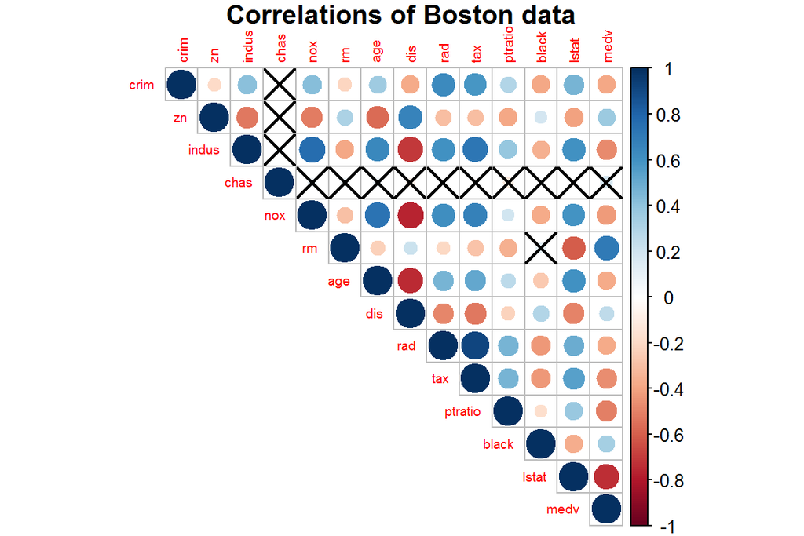

```r
library(corrplot)
p.mat <- cor.mtest(cor_matrix)$p
corrplot(cor_matrix, method="circle", type="upper",  tl.cex = 0.6, p.mat = p.mat, sig.level = 0.01, title="Correlations of Boston data", mar=c(0,0,1,0))
```

**The crime rate strongly positively correlated with accessibility to highways, the property-tax rate and with the lower status.**

## 4.3 Standardizing the dataset

### 4.3.1 Standardizing and printing out summaries

**(Step 4a)**

Values were standardized after data scaling so that the observations of the different variables can be compared with each other. Positive and negative values were created with an overall mean of 0 and a standard deviation of 1.

```r
bos_scaled <- scale(Boston)
summary(bos_scaled)
```

```
##       crim                 zn               indus
##  Min.   :-0.419367   Min.   :-0.48724   Min.   :-1.5563
##  1st Qu.:-0.410563   1st Qu.:-0.48724   1st Qu.:-0.8668
##  Median :-0.390280   Median :-0.48724   Median :-0.2109
##  Mean   : 0.000000   Mean   : 0.00000   Mean   : 0.0000
##  3rd Qu.: 0.007389   3rd Qu.: 0.04872   3rd Qu.: 1.0150
##  Max.   : 9.924110   Max.   : 3.80047   Max.   : 2.4202
##       chas              nox                rm               age
##  Min.   :-0.2723   Min.   :-1.4644   Min.   :-3.8764   Min.   :-2.3331
##  1st Qu.:-0.2723   1st Qu.:-0.9121   1st Qu.:-0.5681   1st Qu.:-0.8366
##  Median :-0.2723   Median :-0.1441   Median :-0.1084   Median : 0.3171
##  Mean   : 0.0000   Mean   : 0.0000   Mean   : 0.0000   Mean   : 0.0000
##  3rd Qu.:-0.2723   3rd Qu.: 0.5981   3rd Qu.: 0.4823   3rd Qu.: 0.9059
##  Max.   : 3.6648   Max.   : 2.7296   Max.   : 3.5515   Max.   : 1.1164
##       dis               rad               tax             ptratio
##  Min.   :-1.2658   Min.   :-0.9819   Min.   :-1.3127   Min.   :-2.7047
##  1st Qu.:-0.8049   1st Qu.:-0.6373   1st Qu.:-0.7668   1st Qu.:-0.4876
##  Median :-0.2790   Median :-0.5225   Median :-0.4642   Median : 0.2746
##  Mean   : 0.0000   Mean   : 0.0000   Mean   : 0.0000   Mean   : 0.0000
##  3rd Qu.: 0.6617   3rd Qu.: 1.6596   3rd Qu.: 1.5294   3rd Qu.: 0.8058
##  Max.   : 3.9566   Max.   : 1.6596   Max.   : 1.7964   Max.   : 1.6372
##      black             lstat              medv
##  Min.   :-3.9033   Min.   :-1.5296   Min.   :-1.9063
##  1st Qu.: 0.2049   1st Qu.:-0.7986   1st Qu.:-0.5989
##  Median : 0.3808   Median :-0.1811   Median :-0.1449
##  Mean   : 0.0000   Mean   : 0.0000   Mean   : 0.0000
##  3rd Qu.: 0.4332   3rd Qu.: 0.6024   3rd Qu.: 0.2683
##  Max.   : 0.4406   Max.   : 3.5453   Max.   : 2.9865
```

### 4.3.2 Creating a categorical variable of the crime rate

**(Step 4b)**

Create a quantile vector of crim

```r
class(bos_scaled)
```

```
## [1] "matrix"
```

```r
bos_scaled <- as.data.frame(bos_scaled)
summary(bos_scaled$crim)
```

```
##      Min.   1st Qu.    Median      Mean   3rd Qu.      Max.
## -0.419367 -0.410563 -0.390280  0.000000  0.007389  9.924110
```

```r
bins <- quantile(bos_scaled$crim)
bins
```

```
##           0%          25%          50%          75%         100%
## -0.419366929 -0.410563278 -0.390280295  0.007389247  9.924109610
```

Create a categorical variable ‘crime’ and look at the table

```r
crime <- cut(bos_scaled$crim, breaks = bins, include.lowest = TRUE, labels = c("low", "med_low", "med_high", "high"))
table(crime)
```

```
## crime
##      low  med_low med_high     high
##      127      126      126      127
```

Remove original crim and add the new categorical value to scaled data

```r
bos_scaled <- dplyr::select(bos_scaled, -crim)
bos_scaled <- data.frame(bos_scaled, crime)
```

We checked the scaled values of rate values and defined the quantiles. Then we named them as low (0-25%), medium low (25-50%), medium high(50-75%) and high (75-100%).Then the quantiles of crime rate quantiles ‘crime’ were added and replaced ‘crim’.

### 4.3.3 Dividing the dataset to train and test sets

**(Step 4c)**

Choose randomly 80% of the rows and create the train set and the test set

```r
n_bos <- nrow(bos_scaled)
ind_bos <- sample(n_bos,  size = n_bos * 0.8)
boston_train <- bos_scaled[ind_bos,]
boston_test <- bos_scaled[-ind_bos,]
```

Save the correct classes from test data

```r
correct_classes <- boston_test$crime
correct_classes
```

```
##   [1] low      low      med_low  med_high med_high med_high med_high
##   [8] med_high med_high low      low      med_low  med_low  low
##  [15] low      med_low  med_low  low      low      med_low  low
##  [22] low      low      med_low  med_low  med_low  med_low  med_low
##  [29] med_low  med_high med_high med_high med_high med_high med_high
##  [36] med_high med_high med_high med_low  med_low  low      low
##  [43] low      med_low  med_low  low      low      low      low
##  [50] med_low  med_low  med_low  med_low  med_low  med_low  med_low
##  [57] low      med_high med_high med_high med_high low      med_low
##  [64] low      med_low  low      low      med_low  low      low
##  [71] med_high med_high med_high low      low      low      low
##  [78] low      low      high     high     high     high     high
##  [85] high     high     high     high     high     high     high
##  [92] high     high     high     high     high     high     high
##  [99] high     high     high     high
## Levels: low med_low med_high high
```

Remove the crime variable from test data set

```r
boston_test <- dplyr::select(boston_test, -crime)
```

## 4.4 Linear discriminant analysis

**(Step 5)**

Fit linear discriminant analysis on the ‘boston_train’ data set using the categorical ‘crime’ as the target variable.

```r
lda.fit <- lda(crime ~ ., data = boston_train)
lda.fit
```

```
## Call:
## lda(crime ~ ., data = boston_train)
##
## Prior probabilities of groups:
##       low   med_low  med_high      high
## 0.2376238 0.2475248 0.2574257 0.2574257
##
## Group means:
##                  zn      indus        chas        nox         rm
## low       0.8671860 -0.8485969 -0.19030615 -0.8630622  0.4101940
## med_low  -0.1172105 -0.2627239 -0.07547406 -0.5410452 -0.1847441
## med_high -0.3948894  0.1789197  0.21980846  0.3465785  0.1023238
## high     -0.4872402  1.0170690 -0.04518867  1.0263404 -0.3282094
##                 age        dis        rad        tax      ptratio
## low      -0.8339186  0.8406002 -0.6971471 -0.7348633 -0.452913751
## med_low  -0.4027126  0.3202213 -0.5500476 -0.4291467 -0.009946484
## med_high  0.3592201 -0.3511215 -0.3756131 -0.2909462 -0.249941864
## high      0.7905465 -0.8503519  1.6386213  1.5144083  0.781350740
##                black        lstat        medv
## low       0.36999537 -0.715425370  0.47076706
## med_low   0.31104125 -0.150826770 -0.03683837
## med_high  0.09915259  0.003071918  0.16883256
## high     -0.79657982  0.809836268 -0.66608744
##
## Coefficients of linear discriminants:
##                  LD1         LD2          LD3
## zn       0.064713197  0.74524778 -0.908970410
## indus    0.005855833 -0.24857245  0.091501918
## chas    -0.092210600 -0.10691445  0.060138540
## nox      0.395961661 -0.72837304 -1.144675082
## rm      -0.089262903 -0.06315898 -0.259855052
## age      0.244696221 -0.23988852 -0.261379062
## dis     -0.057066293 -0.21888082 -0.007249824
## rad      3.079385046  0.76714473 -0.417017083
## tax     -0.087455797  0.11725343  0.880884627
## ptratio  0.128269592  0.01928150 -0.123383068
## black   -0.137291621  0.01118952  0.079985876
## lstat    0.218280464 -0.20881241  0.217992605
## medv     0.173541485 -0.40568071 -0.226754787
##
## Proportion of trace:
##    LD1    LD2    LD3
## 0.9522 0.0354 0.0125
```

The function for lda biplot arrows

```r
lda.arrows <- function(x, myscale = 1, arrow_heads = 0.1, color = "orange", tex = 0.75, choices = c(1,2)){
  heads <- coef(x)
  arrows(x0 = 0, y0 = 0,
         x1 = myscale * heads[,choices[1]],
         y1 = myscale * heads[,choices[2]], col=color, length = arrow_heads)
  text(myscale * heads[,choices], labels = row.names(heads),
       cex = tex, col=color, pos=3)
}
```

Target classes as numeric and plot the lda results

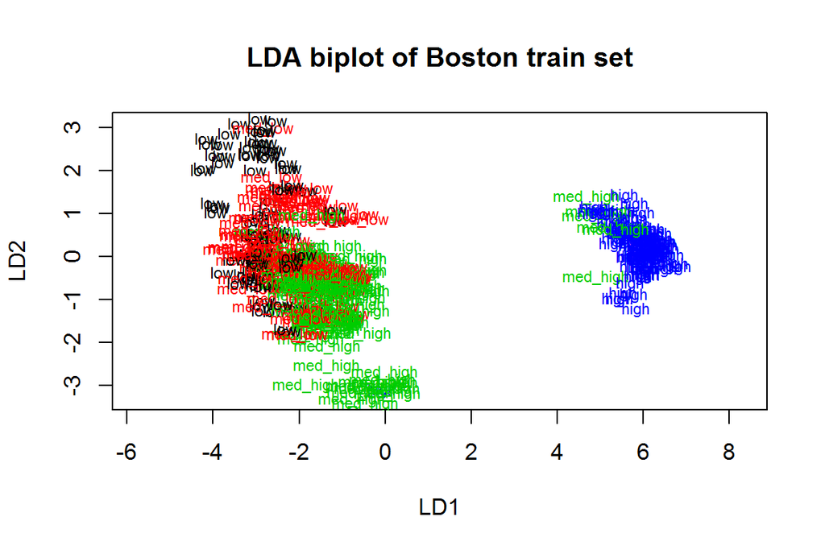

```r
classes <- as.numeric(boston_train$crime)
plot(lda.fit, dimen = 2, col = classes, pch = classes, main = "LDA biplot of Boston train set")
```

The linear discriminant analysis showed the separation of different crime rates.

**Note: I do not know why the arrow were not desplayed.**

**Error in arrows(x0 = 0, y0 = 0, x1 = myscale * heads[, choices[1]], y1 = myscale * : plot.new has not been called yet**

## 4.5 Predicting the classes with the LDA model

Now we Use the LDA outcome to perform a prediction on the crime rate on the test set.

### 4.5.1 Predicting classes with test data

**(Step 6a)**

```r
lda.pred <- predict(lda.fit, newdata = boston_test)
```

### 4.5.2 Cross tabulate the results with the crime categories

**(Step 6b)**

```r
pred_table <- table(correct = correct_classes, predicted = lda.pred$class)
pred_table
```

```
##           predicted
## correct    low med_low med_high high
##   low       20      11        0    0
##   med_low    4      18        4    0
##   med_high   0       6       16    0
##   high       0       0        0   23
```

The results were not very good on lower crime rate predictions. The predicted crime rate was higher than it actually was: predicted med_low of and med_high which were low rates or med_low rates. However, the predictions on the high crime rates was good.

## 4.6 Reloading the dataset and run k-means algorithm

In 4.5, we performed classification.In classification, the classes are defined before (crime rate values from low to high) and the classification model is trained based on data.

Now we do Clustering. The classes / number of classes is unknown and we will find groups based on similarity of the observations.

### 4.6.1 Standardizing the Boston dataset

**(Step 7a)**

```r
data(Boston)
bos_scaled2 <- scale(Boston)
```

### 4.6.2 Calculating the distances

**(Step 7b)**

Euclidean distance matrix

```r
dist_eu <- dist(bos_scaled2)
summary(dist_eu)
```

```
##    Min. 1st Qu.  Median    Mean 3rd Qu.    Max.
##  0.1343  3.4625  4.8241  4.9111  6.1863 14.3970
```

Manhattan distance matrix

```r
dist_man <- dist(bos_scaled2, method = "manhattan")
summary(dist_man)
```

```
##    Min. 1st Qu.  Median    Mean 3rd Qu.    Max.
##  0.2662  8.4832 12.6090 13.5488 17.7568 48.8618
```

### 4.6.3 K-means clustering

**(Step 7c)**

```r
bos_km <- kmeans(bos_scaled2, centers = 3)
```

Plot the dataset with clusters

[figure not shown]

```r
pairs(bos_scaled2, col = bos_km$cluster)
```

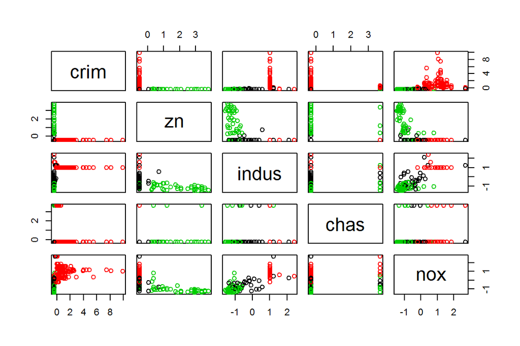

```r
pairs(bos_scaled2[,1:5], col = bos_km$cluster)
```

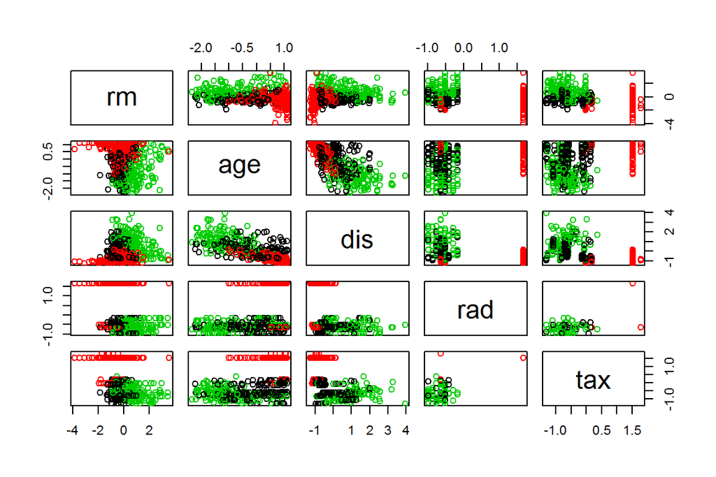

```r
pairs(bos_scaled2[,6:10], col = bos_km$cluster)
```

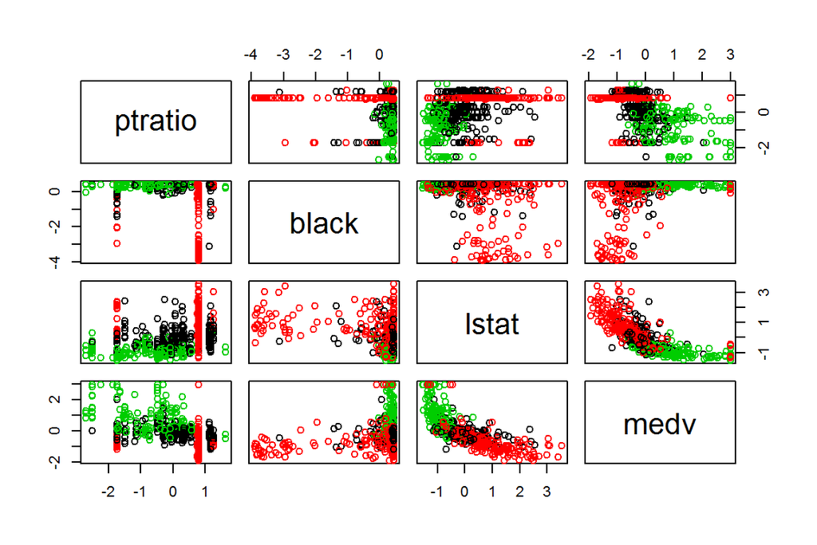

```r
pairs(bos_scaled2[,11:14], col = bos_km$cluster)
```

### 4.6.4 Determining the k

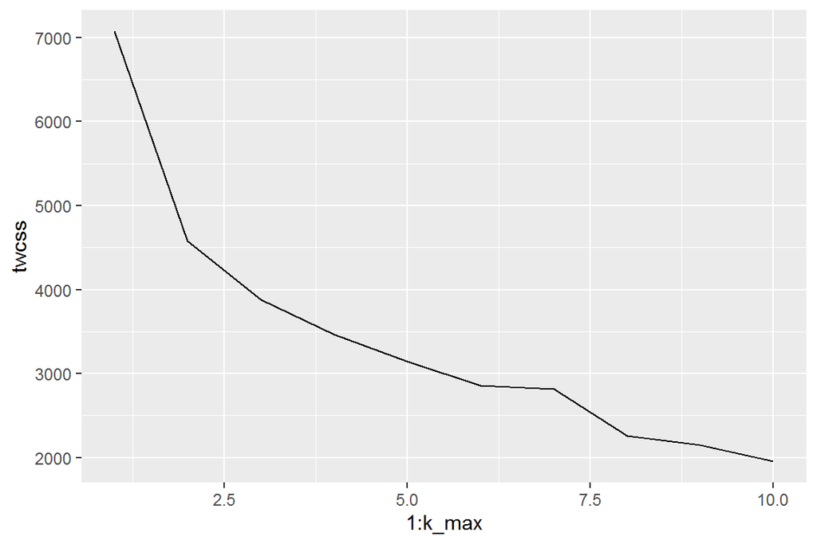

```r
set.seed(123)
k_max <- 10 # determine the number of clusters
twcss <- sapply(1:k_max, function(k){kmeans(bos_scaled2, k)$tot.withinss}) # calculate the total within sum of squares
qplot(x = 1:k_max, y = twcss, geom = 'line') # visualize the results
```

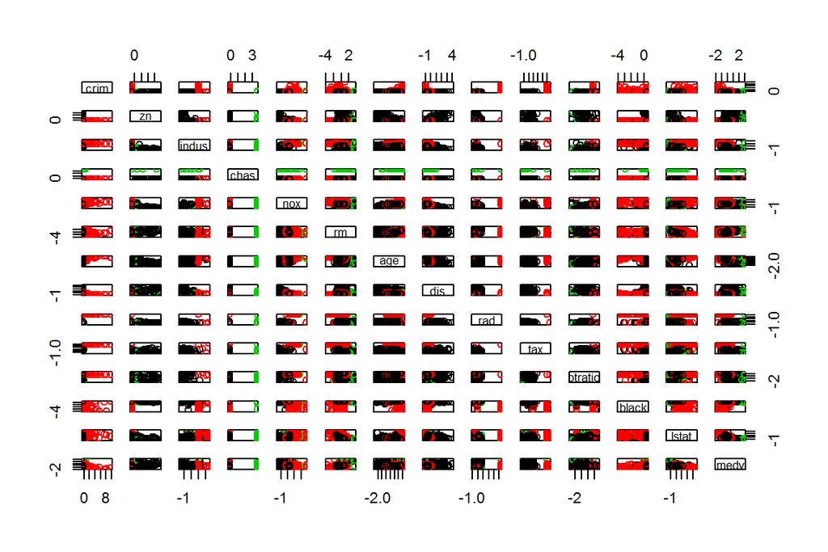

```r
bos_km2 <- kmeans(bos_scaled2, centers = 3) # k-means clustering
pairs(bos_scaled2, col = bos_km2$cluster) # plot the data with clusters
```

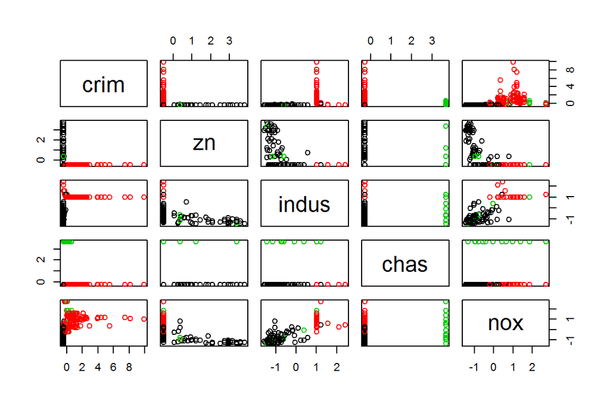

```r
pairs(bos_scaled2[,1:5], col = bos_km2$cluster)
```

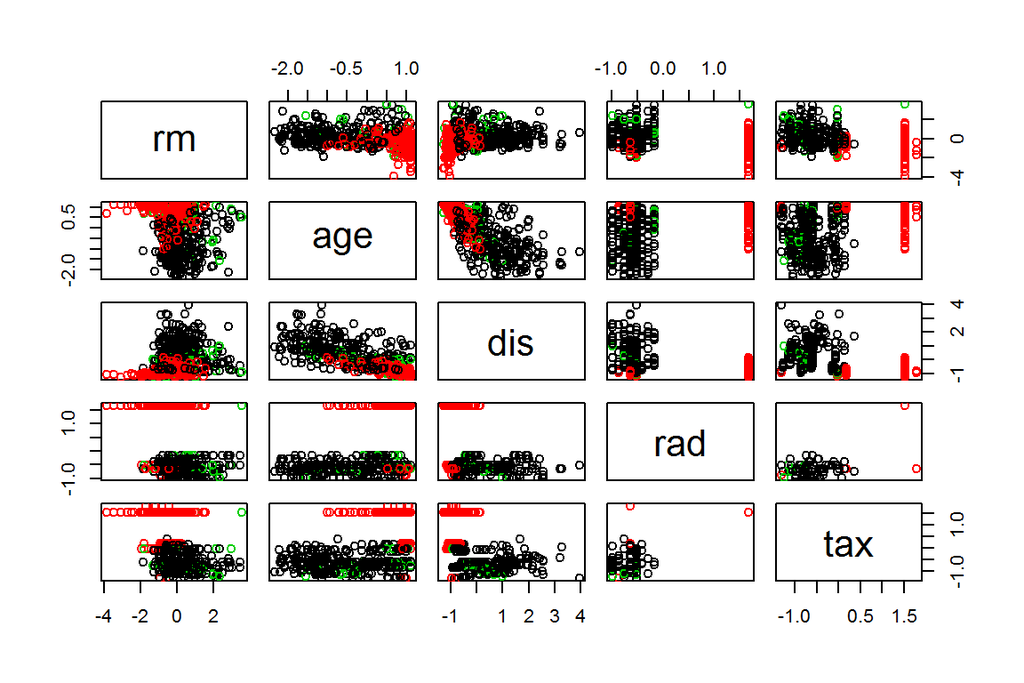

```r
pairs(bos_scaled2[,6:10], col = bos_km2$cluster)
```

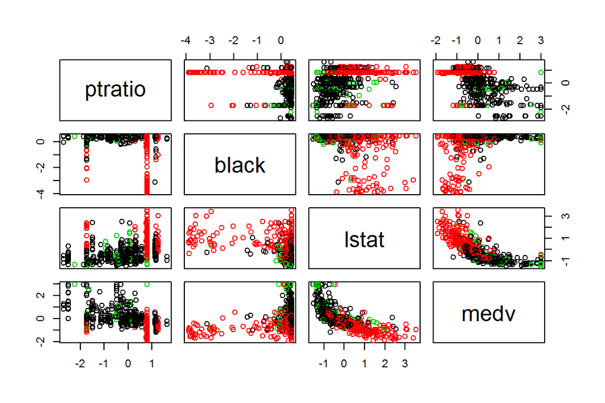

```r
pairs(bos_scaled2[,11:14], col = bos_km2$cluster)
```

The twcss value decrease heavily at a level of 2 - 3 clusters. The optimal number of clusters was 3.

## 4.7 Performing k-means on the original data

**(Bonus)**

```r
data(Boston)
bos_scaled3 <- scale(Boston)
bos_km3 <-kmeans(bos_scaled3, centers = 3)
cluster <- bos_km3$cluster
bos_scaled3 <- data.frame(bos_scaled3, cluster)
lda.fit_cluster <- lda(cluster ~ ., data = bos_scaled3)
lda.fit_cluster
```

```
## Call:
## lda(cluster ~ ., data = bos_scaled3)
##
## Prior probabilities of groups:
##         1         2         3
## 0.2470356 0.3260870 0.4268775
##
## Group means:
##         crim         zn      indus         chas        nox         rm
## 1 -0.3989700  1.2614609 -0.9791535 -0.020354653 -0.8573235  1.0090468
## 2  0.7982270 -0.4872402  1.1186734  0.014005495  1.1351215 -0.4596725
## 3 -0.3788713 -0.3578148 -0.2879024  0.001080671 -0.3709704 -0.2328004
##           age        dis        rad        tax     ptratio      black
## 1 -0.96130713  0.9497716 -0.5867985 -0.6709807 -0.80239137  0.3552363
## 2  0.79930921 -0.8549214  1.2113527  1.2873657  0.59162230 -0.6363367
## 3 -0.05427143  0.1034286 -0.5857564 -0.5951053  0.01241316  0.2805140
##        lstat        medv
## 1 -0.9571271  1.06668290
## 2  0.8622388 -0.67953738
## 3 -0.1047617 -0.09820229
##
## Coefficients of linear discriminants:
##                 LD1         LD2
## crim    -0.03206338 -0.19094456
## zn       0.02935900 -1.07677218
## indus    0.63347352 -0.09917524
## chas     0.02460719  0.10009606
## nox      1.11749317 -0.75995105
## rm      -0.18841682 -0.57360135
## age     -0.12983139  0.47226685
## dis      0.04493809 -0.34585958
## rad      0.67004295 -0.08584353
## tax      1.03992455 -0.58075025
## ptratio  0.25864960 -0.02605279
## black   -0.01657236  0.01975686
## lstat    0.17365575 -0.41704235
## medv    -0.06819126 -0.79098605
##
## Proportion of trace:
##    LD1    LD2
## 0.8506 0.1494
```

```r
lda.arrows <- function(x, myscale = 1, arrow_heads = 0.1, color = "orange", tex = 0.75, choices = c(1,2)){
  heads <- coef(x)
  arrows(x0 = 0, y0 = 0,
         x1 = myscale * heads[,choices[1]],
         y1 = myscale * heads[,choices[2]], col=color, length = arrow_heads)
  text(myscale * heads[,choices], labels = row.names(heads),
       cex = tex, col=color, pos=3)
}
```

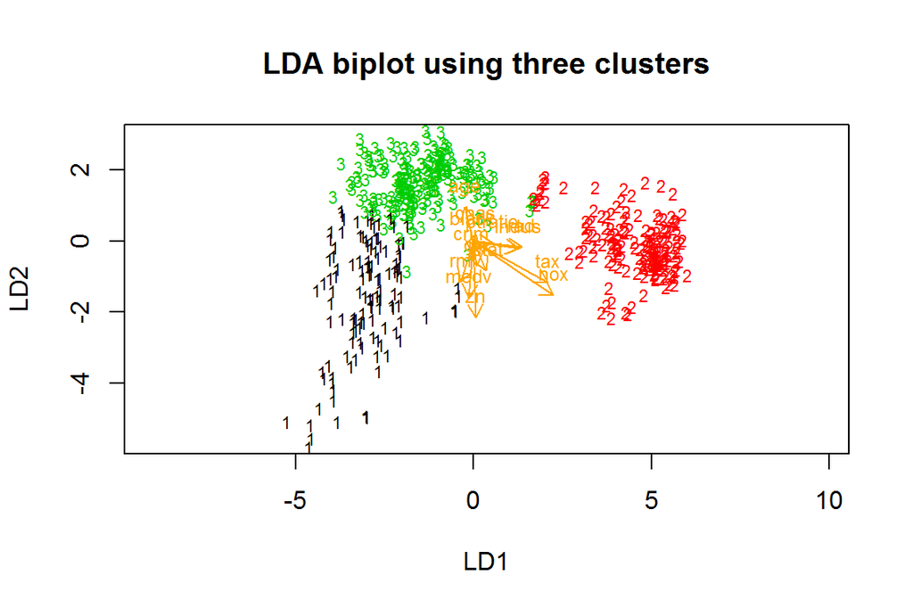

```r
classes3 <- as.numeric(bos_scaled3$cluster)
plot(lda.fit_cluster, dimen = 2, col = classes3, pch = classes3, main = "LDA biplot using three clusters")
lda.arrows(lda.fit_cluster, myscale = 2)
```

## 4.8 3D plot

**(Super-Bonus)**

```r
model_predictors <- dplyr::select(boston_train, -crime)
# check the dimensions
dim(model_predictors)
```

```
## [1] 404  13
```

```r
dim(lda.fit$scaling)
```

```
## [1] 13  3
```

```r
# matrix multiplication
matrix_product <- as.matrix(model_predictors) %*% lda.fit$scaling
matrix_product <- as.data.frame(matrix_product)
```

Next, install and access the plotly package. Create a 3D plot of the columns of the matrix product.

**Note:** After running:

**plot_ly(x = matrix_product$LD1, y = matrix_product$LD2, z = matrix_product$LD3, type= 'scatter3d', mode='markers', color = boston_train$crime)**

It showed:

WebGL is not supported by your browser. Therefore I cannot see a cool plot.

# Chapter 5 Dimensionality reduction techniques

(25.11.-2.12.2019)

- **Data wrangling**

  R script of data Wrangling exercise is available here.

  https://github.com/yufanyin/IODS-project/blob/master/create_human.R

## 5.1 Exploring the data numerically and graphically

Load necessary packages

```r
library(tidyr)
library(dplyr)
library(corrplot)
library(ggplot2)
library(GGally)
library(knitr)
library(kableExtra)
library(stringr)
library(ggfortify)
library(factoextra)
```

### 5.1.1 Reading the data

```r
human <- read.table(file = "G:/C-Open Data Science/0-191030/IODS-project-master/human_ana.txt")
```

### 5.1.2 Summaries of the variables

**(Step 1a)**

The data are the conbination of two data sets, Human Development Index (HDI) and Gender Inequality Index.

The data consist of 155 observations in 8 variables.

“Country”: country name “edu2F_edu2M”: ratio of second education of female/male “labF_labM”: ratio of labour forced female/male “exp_edu”: expected years of education “exp_life”: life expectancy at birth “GNI”: Gross National Income per capita “mat_mor”: maternal mortality ratio “ado_birth”: adolescent birth rate “F_parli”: percetange of female representatives in parliament

```r
knitr::kable(summary(human)) %>% kable_styling(bootstrap_options = "striped", position = "center", font_size = 12)
```

|  | edu2F_edu2M | labF_labM | exp_edu | exp_life | GNI | mat_mor | ado_birth | F_parli |
| --- | --- | --- | --- | --- | --- | --- | --- | --- |
|  | Min. :0.1717 | Min. :0.1857 | Min. : 5.40 | Min. :49.00 | Min. : 581 | Min. : 1.0 | Min. : 0.60 | Min. : 0.00 |
|  | 1st Qu.:0.7264 | 1st Qu.:0.5984 | 1st Qu.:11.25 | 1st Qu.:66.30 | 1st Qu.: 4198 | 1st Qu.: 11.5 | 1st Qu.: 12.65 | 1st Qu.:12.40 |
|  | Median :0.9375 | Median :0.7535 | Median :13.50 | Median :74.20 | Median : 12040 | Median : 49.0 | Median : 33.60 | Median :19.30 |
|  | Mean :0.8529 | Mean :0.7074 | Mean :13.18 | Mean :71.65 | Mean : 17628 | Mean : 149.1 | Mean : 47.16 | Mean :20.91 |
|  | 3rd Qu.:0.9968 | 3rd Qu.:0.8535 | 3rd Qu.:15.20 | 3rd Qu.:77.25 | 3rd Qu.: 24512 | 3rd Qu.: 190.0 | 3rd Qu.: 71.95 | 3rd Qu.:27.95 |
|  | Max. :1.4967 | Max. :1.0380 | Max. :20.20 | Max. :83.50 | Max. :123124 | Max. :1100.0 | Max. :204.80 | Max. :57.50 |

### 5.1.3 Graphical overview of the data

**(Step 1b)**

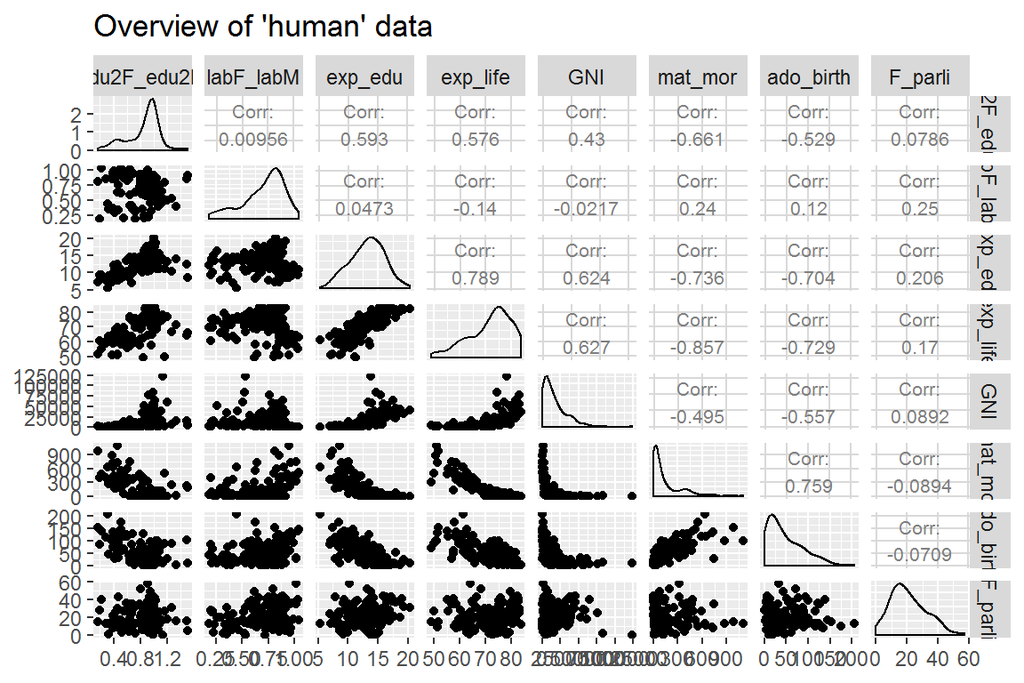

```r
ov_human <- ggpairs(human, mapping = aes(), title ="Overview of 'human' data", lower = list(combo = wrap("facethist", bins = 20)), upper = list(continuous = wrap("cor", size = 2.8)))
ov_human
```

### 5.1.4 Relationships between the variables

**(Step 1c)**

```r
cor_human <- cor(human) %>% round(digits = 2)
cor_human %>% knitr::kable(caption = "Correlation between variables") %>%
  kable_styling(bootstrap_options = "striped", full_width = FALSE, position = "center")
```

Correlation between variables

|  | edu2F_edu2M | labF_labM | exp_edu | exp_life | GNI | mat_mor | ado_birth | F_parli |
| --- | --- | --- | --- | --- | --- | --- | --- | --- |
| edu2F_edu2M | 1.00 | 0.01 | 0.59 | 0.58 | 0.43 | -0.66 | -0.53 | 0.08 |
| labF_labM | 0.01 | 1.00 | 0.05 | -0.14 | -0.02 | 0.24 | 0.12 | 0.25 |
| exp_edu | 0.59 | 0.05 | 1.00 | 0.79 | 0.62 | -0.74 | -0.70 | 0.21 |
| exp_life | 0.58 | -0.14 | 0.79 | 1.00 | 0.63 | -0.86 | -0.73 | 0.17 |
| GNI | 0.43 | -0.02 | 0.62 | 0.63 | 1.00 | -0.50 | -0.56 | 0.09 |
| mat_mor | -0.66 | 0.24 | -0.74 | -0.86 | -0.50 | 1.00 | 0.76 | -0.09 |
| ado_birth | -0.53 | 0.12 | -0.70 | -0.73 | -0.56 | 0.76 | 1.00 | -0.07 |
| F_parli | 0.08 | 0.25 | 0.21 | 0.17 | 0.09 | -0.09 | -0.07 | 1.00 |

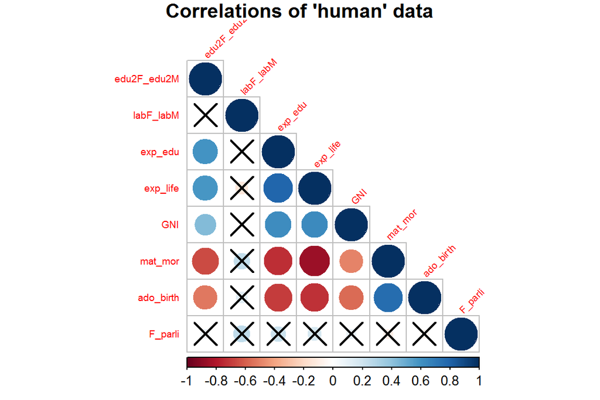

```r
p.mat <- cor.mtest(cor_human)$p
corrplot(cor_human, method="circle",  type="lower",  tl.cex = 0.6, p.mat = p.mat, sig.level = 0.01, tl.srt = 45, title="Correlations of 'human' data", mar=c(0,0,1,0))
```

Expected years of education strongly positively correlated with Live expectation and strongly negatively correlated with maternal mortality ratio. It indicated that a better education leads to a higher life expectation and contributes to a lower maternal mortality.

Another strong positive correlation was seen between adolescent birth rate and maternal mortality ratio. This may be due to high quality of medical care.

## 5.2 Principal component analysis (PCA) on non-standardized data

In PCA, the data are first transformed to a new space with equal or less number of dimensions which called the principal components. The 1st principal component captures the maximum amount of variance from the features in the original data. The 2nd principal component is orthogonal to the first and it captures the maximum amount of variability left.

### 5.2.1 Variability captured by the principal components

**(Step 2a)**

```r
pca_human <- prcomp(human)
round(pca_human$rotation[,1:2], digits = 4) %>% knitr::kable(caption = "PCA result on all variables") %>% kable_styling(bootstrap_options = "striped", full_width = FALSE, position = "center")
```

PCA result on all variables

|  | PC1 | PC2 |
| --- | --- | --- |
| edu2F_edu2M | 0.0000 | 0.0007 |
| labF_labM | 0.0000 | -0.0003 |
| exp_edu | -0.0001 | 0.0076 |
| exp_life | -0.0003 | 0.0283 |
| GNI | -1.0000 | -0.0058 |
| mat_mor | 0.0057 | -0.9916 |
| ado_birth | 0.0012 | -0.1256 |
| F_parli | -0.0001 | 0.0032 |

```r
s1 <- summary(pca_human)
pca_prc1 <- round(100 * s1$importance[2, ], digits = 3)
round(100 * s1$importance[2, 1:2], digits = 5) %>% knitr::kable(caption = "Principle components") %>% kable_styling(bootstrap_options = "striped", full_width = FALSE, position = "center")
```

Principle components

|  | x |
| --- | --- |
| PC1 | 99.99 |
| PC2 | 0.01 |

### 5.2.2 PCA Biplot displaying the observations by the first two principal components

**(Step 2b)**

The biplot displayed the observations by the first two principal components (PC1 coordinate in x-axis, PC2 coordinate in y-axis), along with arrows representing the original variables.

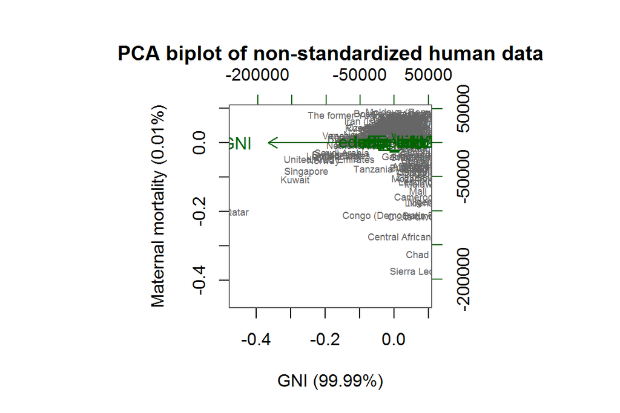

```r
pca_label1 <-  paste0("GNI (", pca_prc1[1],"%)" )
pca_label2 <-  paste0("Maternal mortality (", pca_prc1[2],"%)" )
biplot(pca_human, choices = 1:2, cex = c(0.55, 0,9), col = c("grey40", "darkgreen"), xlab = pca_label1, ylab = pca_label2, main = "PCA biplot of non-standardized human data", margin =c(0,0,5,0))
```

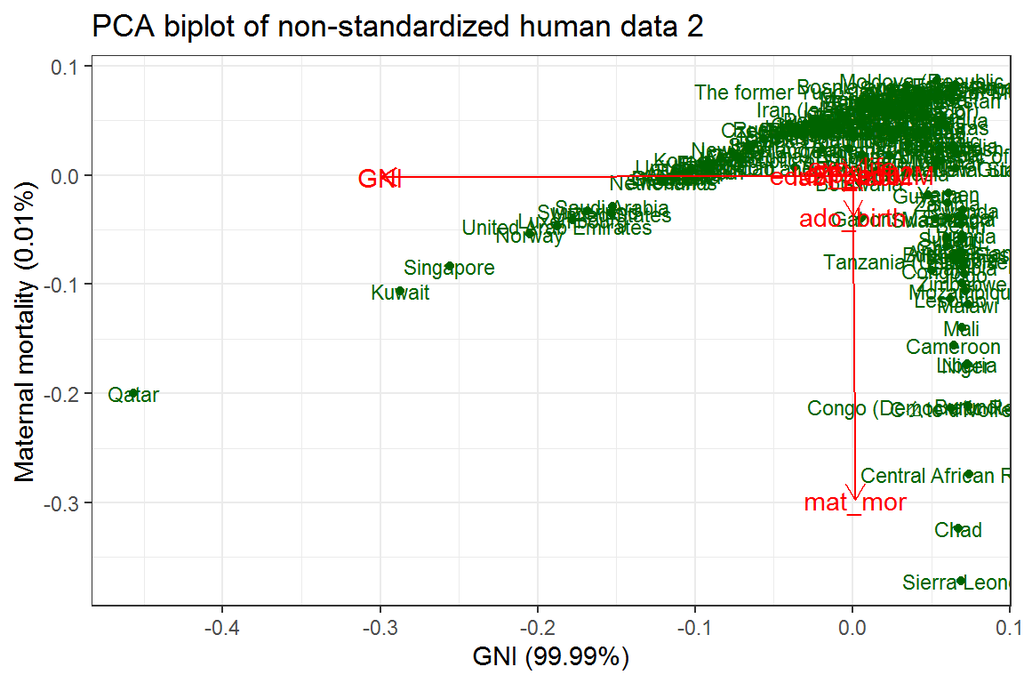

```r
autoplot(pca_human, data = human, label= TRUE, label.size = 3.0, colour = "darkgreen", loadings = TRUE, loadings.label = TRUE, loadings.colour = "red",) + ggtitle("PCA biplot of non-standardized human data 2") + xlab(paste0(pca_label1))  + ylab(paste0(pca_label2)) + theme_bw()
```

Principal component 1 (GNI) represents 99.99% of the variance of the non-standardized data. PC2 (maternal mortalility ratio) captures 0.01% of the variance. The Gross National Income per capita explains 99.99% of the principal component 1 of the data.

## 5.3 Principal component analysis (PCA) on standardized data

### 5.3.1 Scaling the data

**(Step 3a)**

The summary of the standardized data is as follows (The mean of all values is 0 and the standard diviation reaches 1).

```r
stzd_human <- scale(human)
knitr::kable(summary(stzd_human)) %>%
  kable_styling(bootstrap_options = "striped", position = "center", font_size = 11)
```

|  | edu2F_edu2M | labF_labM | exp_edu | exp_life | GNI | mat_mor | ado_birth | F_parli |
| --- | --- | --- | --- | --- | --- | --- | --- | --- |
|  | Min. :-2.8189 | Min. :-2.6247 | Min. :-2.7378 | Min. :-2.7188 | Min. :-0.9193 | Min. :-0.6992 | Min. :-1.1325 | Min. :-1.8203 |
|  | 1st Qu.:-0.5233 | 1st Qu.:-0.5484 | 1st Qu.:-0.6782 | 1st Qu.:-0.6425 | 1st Qu.:-0.7243 | 1st Qu.:-0.6496 | 1st Qu.:-0.8394 | 1st Qu.:-0.7409 |
|  | Median : 0.3503 | Median : 0.2316 | Median : 0.1140 | Median : 0.3056 | Median :-0.3013 | Median :-0.4726 | Median :-0.3298 | Median :-0.1403 |
|  | Mean : 0.0000 | Mean : 0.0000 | Mean : 0.0000 | Mean : 0.0000 | Mean : 0.0000 | Mean : 0.0000 | Mean : 0.0000 | Mean : 0.0000 |
|  | 3rd Qu.: 0.5958 | 3rd Qu.: 0.7350 | 3rd Qu.: 0.7126 | 3rd Qu.: 0.6717 | 3rd Qu.: 0.3712 | 3rd Qu.: 0.1932 | 3rd Qu.: 0.6030 | 3rd Qu.: 0.6127 |
|  | Max. : 2.6646 | Max. : 1.6632 | Max. : 2.4730 | Max. : 1.4218 | Max. : 5.6890 | Max. : 4.4899 | Max. : 3.8344 | Max. : 3.1850 |

### 5.3.2 Variability captured by the principal components

**(Step 3b)**

```r
pca_stzd_human <- prcomp(stzd_human)
round(pca_stzd_human$rotation[, 1:2], digits = 4) %>% knitr::kable(caption = "PC1 & 2 of standardized 'human' data") %>% kable_styling(bootstrap_options = "striped", full_width = FALSE, position = "center")
```

PC1 & 2 of standardized ‘human’ data

|  | PC1 | PC2 |
| --- | --- | --- |
| edu2F_edu2M | -0.3566 | 0.0380 |
| labF_labM | 0.0546 | 0.7243 |
| exp_edu | -0.4277 | 0.1394 |
| exp_life | -0.4437 | -0.0253 |
| GNI | -0.3505 | 0.0506 |
| mat_mor | 0.4370 | 0.1451 |
| ado_birth | 0.4113 | 0.0771 |
| F_parli | -0.0844 | 0.6514 |

```r
s2 <- summary(pca_stzd_human)
pca_prc2 <- round(100 * s2$importance[2, ], digits = 1)

pca_label2.1 <- paste0("Education and health (",pca_prc2[1],"%) ")
pca_label2.2 <- paste0("Female social participation (",pca_prc2[2],"%) ")

round(100 * s2$importance[2, 1:2], digits = 2) %>% knitr::kable(caption = "Principle components") %>% kable_styling(bootstrap_options = "striped", full_width = FALSE, position = "center")
```

Principle components

|  | x |
| --- | --- |
| PC1 | 53.61 |
| PC2 | 16.24 |

### 5.3.3 PCA Biplot

**(Step 3c)**

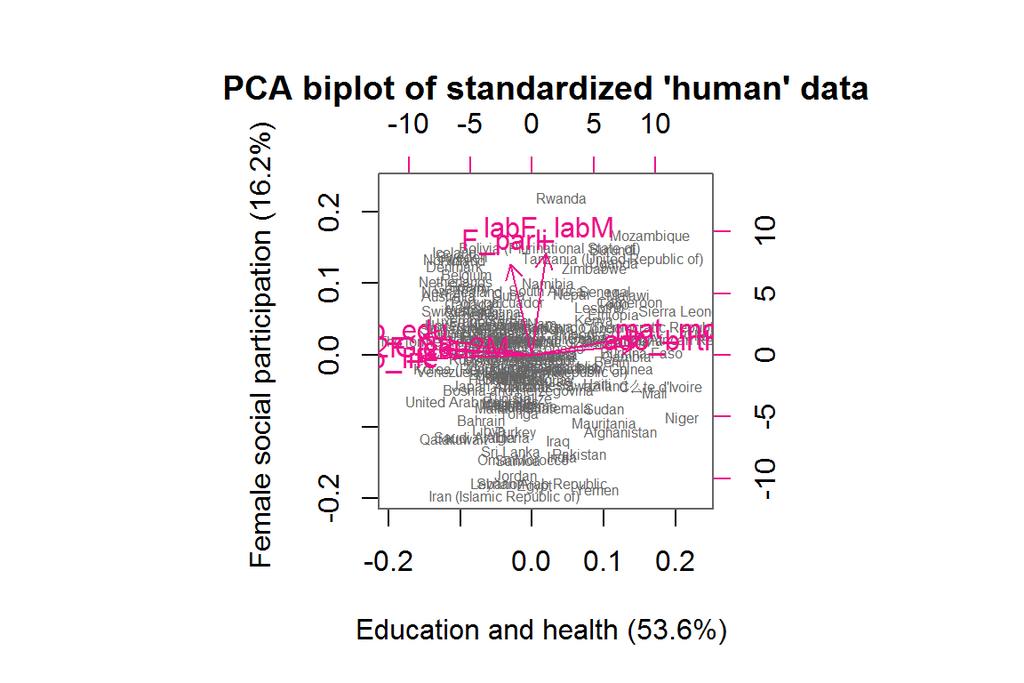

```r
biplot(pca_stzd_human, choices = 1:2, cex = c(0.5, 0,9), col = c("grey40", "deeppink2"), xlab = pca_label2.1, ylab = pca_label2.2, main = "PCA biplot of standardized 'human' data", margin =c(0,0,5,0))
```

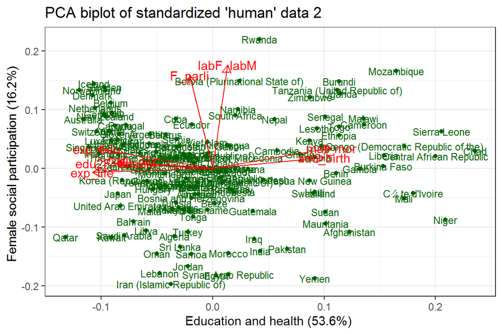

```r
autoplot(prcomp(stzd_human), data = human, colour = "darkgreen", label= TRUE, label.size = 3.0, loadings = TRUE, loadings.label = TRUE, loadings.colour = "red",) + ggtitle("PCA biplot of standardized 'human' data 2") + xlab(paste0(pca_label2.1))  + ylab(paste0(pca_label2.2)) + theme_bw()
```

### 5.3.4 Interpretations of the first two principal component dimensions

**(Step 4)**

The principal component representing 16.2% of the data variation was strongly associated with percentage of parliament representatives (“F_parli”) and ratio of labour forced female/male (“labF_labM”). So the share of of woman in labour market and in the political representatives were mostly associated with principal component 2. The variables which showed the strongest association with principal component 1 and represented 53.6% of the data variation were life expectancy (“exp_life”), expected years of education (“exp_edu”), the ratio of second education of female/male (“edu2F_edu2M”), adolescent birth rate (“ado_birth”) and maternal mortality ratio (“mat_mor”). Hence principal component 1 discribed the health and education situation in those countries.

The PCA result on between non-standardized data differed from that on standardized data. In the PCA of the non-standardized human data, the principal component 1 represents almost all varation and Gross National Income per capita is the value representing principle component 1. The PCA of standardized values looks quite different. The PC1 & PC2 values spread all over the biplot and more variables are associated to these two principal components. To perform the PCA, it is necessary to standardizing variables of obsvervations so that values become comparable. **(Before doing this exercise, I did not know why I needed to standardize first! Now I understand.)**

The angle between the arrows represents the original features of the data and can be interpreted as the correlation between these features. Small angle between the arrows means that the correlation is positive. The angle between the feature and the principal component can be interpreted as the correlation between these two components. Similarly, if the angle is small there is a positive correlation. The length of the arrows is proportional to the standard deviation of the features.

## 5.4 Multiple Correspondence Analysis (MCA)

### 5.4.1 Structure and dimensions of ‘tea’ data

**(Step 5a)**

The tea data about tea consumption behaviour were loaded from the package Factominer. The data consist of 300 observations in 36 variables.

```r
library(FactoMineR)
data(tea)
dim(tea)
```

```
## [1] 300  36
```

```r
str(tea)
```

```
## 'data.frame':    300 obs. of  36 variables:
##  $ breakfast       : Factor w/ 2 levels "breakfast","Not.breakfast": 1 1 2 2 1 2 1 2 1 1 ...
##  $ tea.time        : Factor w/ 2 levels "Not.tea time",..: 1 1 2 1 1 1 2 2 2 1 ...
##  $ evening         : Factor w/ 2 levels "evening","Not.evening": 2 2 1 2 1 2 2 1 2 1 ...
##  $ lunch           : Factor w/ 2 levels "lunch","Not.lunch": 2 2 2 2 2 2 2 2 2 2 ...
##  $ dinner          : Factor w/ 2 levels "dinner","Not.dinner": 2 2 1 1 2 1 2 2 2 2 ...
##  $ always          : Factor w/ 2 levels "always","Not.always": 2 2 2 2 1 2 2 2 2 2 ...
##  $ home            : Factor w/ 2 levels "home","Not.home": 1 1 1 1 1 1 1 1 1 1 ...
##  $ work            : Factor w/ 2 levels "Not.work","work": 1 1 2 1 1 1 1 1 1 1 ...
##  $ tearoom         : Factor w/ 2 levels "Not.tearoom",..: 1 1 1 1 1 1 1 1 1 2 ...
##  $ friends         : Factor w/ 2 levels "friends","Not.friends": 2 2 1 2 2 2 1 2 2 2 ...
##  $ resto           : Factor w/ 2 levels "Not.resto","resto": 1 1 2 1 1 1 1 1 1 1 ...
##  $ pub             : Factor w/ 2 levels "Not.pub","pub": 1 1 1 1 1 1 1 1 1 1 ...
##  $ Tea             : Factor w/ 3 levels "black","Earl Grey",..: 1 1 2 2 2 2 2 1 2 1 ...
##  $ How             : Factor w/ 4 levels "alone","lemon",..: 1 3 1 1 1 1 1 3 3 1 ...
```

[output cut: 22 more lines]

### 5.4.2 Visualization of ‘tea’ data

**(Step 5b)**

**Error in the following chunk:**

Warning: attributes are not identical across measure variables;

they will be dropped

**WHY?** The error occurred in knitting index.rmd. Everything was fine when I knitted chapter5.rmd

I had to add #### so that all the following codes would be able to display without running.

```r
# column names to keep in the dataset
#### keep_tea <- c("Tea", "How", "how", "price", "where", "lunch")
#### keep_tea

# select and create a new dataset
#### tea_time <- select(tea, one_of(keep_tea))

#### gather(tea_time) %>% ggplot(aes(value)) + facet_wrap("key", scales = "free") + geom_bar(fill = "darkblue") + theme(axis.text.x = element_text(angle = 45, hjust = 1, size = 8))
```

### 5.4.3 Multiple Correspondence Analysis and its summary

**(Step 5c)**

```r
#### mca_tea_time <- MCA(tea_time, graph = FALSE)
#### summary(mca_tea_time)
```

Visualize MCA

```r
#### plot(mca_tea_time, invisible=c("ind"), habillage = "quali")
```

### 5.4.4 MCA biplot of tea consumption behaviour

**(Step 5d)**

An individual value between 0 & 1 was added to colour the cosine-squared (cos2), a value between 0 & 1. The closer to 1, the better this value projected on the dimension.

```r
#### fviz_mca_biplot(mca_tea_time, col.ind = "cos2", col.var = "darkred", label = "var", geom =  c("point","text"), labelsize = 4, arrows = c(FALSE,TRUE)) + labs(title = "MCA of tea consumption behaviour") + theme_grey() + theme(axis.line = element_line(size = 0.5), panel.background = element_rect(fill = "gray93"))
```

### 5.4.5 MCA of reason for drinking tea

**(Step 5e)**

“sex”: Gender of tea consumers “age_Q”: Age group of tea consumers “spirituality”: Spiritual reason “healthy”: Health reason “slimming”: To lose weight or not “relaxing”: Relaxation or not

**(Same error in this chunk)**

```r
#### keep_reason <- c("sex", "age_Q", "spirituality", "healthy", "slimming", "relaxing")
#### tea_reason <- select(tea, one_of(keep_reason))

#### gather(tea_reason) %>% ggplot(aes(value)) + facet_wrap("key", scales = "free") + geom_bar(fill = "darkblue", alpha = 0.6) + theme(axis.text.x = element_text(angle = 45, hjust = 1, size = 8))
```

MCA of ‘tea_reason’ data

```r
#### mca_tea_reason <- MCA(tea_reason, graph = FALSE)
#### summary(mca_tea_reason)
```

Call: MCA(X = tea_reason, graph = FALSE)

Eigenvalues

```
                Dim.1   Dim.2   Dim.3   Dim.4   Dim.5   Dim.6
```

Variance 0.233 0.217 0.202 0.173 0.166 0.138

% of var. 15.562 14.476 13.456 11.502 11.066 9.187

Cumulative % of var. 15.562 30.039 43.495 54.997 66.063 75.251

```
                Dim.7   Dim.8   Dim.9
```

Variance 0.132 0.126 0.113

% of var. 8.833 8.393 7.523

Cumulative % of var. 84.083 92.477 100.000

Individuals (the 10 first)

```
             Dim.1    ctr   cos2    Dim.2    ctr   cos2    Dim.3
```

1 | 0.491 0.344 0.135 | 0.199 0.061 0.022 | 0.110

2 | 0.506 0.366 0.210 | 0.599 0.551 0.294 | -0.564

3 | 0.039 0.002 0.001 | 0.353 0.191 0.119 | -0.380

4 | -0.602 0.518 0.306 | -0.531 0.432 0.237 | 0.178

5 | 0.208 0.062 0.024 | -0.446 0.305 0.112 | -0.116

6 | -0.270 0.104 0.081 | -0.288 0.128 0.093 | 0.198

7 | 0.024 0.001 0.000 | -0.047 0.003 0.001 | 0.294

8 | -0.193 0.053 0.025 | 0.146 0.033 0.014 | -0.211

9 | 0.308 0.135 0.049 | -0.410 0.259 0.088 | 0.073

10 | 0.024 0.001 0.000 | -0.047 0.003 0.001 | 0.294

```
             ctr   cos2
```

1 0.020 0.007 |

2 0.526 0.261 |

3 0.239 0.138 |

4 0.052 0.027 |

5 0.022 0.008 |

6 0.065 0.044 |

7 0.143 0.054 |

8 0.074 0.030 |

9 0.009 0.003 |

10 0.143 0.054 |

Categories (the 10 first)

```
              Dim.1     ctr    cos2  v.test     Dim.2     ctr
```

F | -0.256 2.767 0.095 -5.338 | 0.220 2.198

M | 0.373 4.037 0.095 5.338 | -0.321 3.208

15-24 | -0.834 15.237 0.308 -9.593 | -0.524 6.472

25-34 | 0.681 7.619 0.139 6.437 | -0.744 9.760

35-44 | 0.018 0.003 0.000 0.121 | 0.149 0.229

45-59 | 0.692 6.948 0.122 6.043 | 0.728 8.276

+60 | -0.346 1.086 0.017 -2.282 | 1.293 16.262

Not.spirituality | 0.302 4.458 0.199 7.719 | 0.212 2.374

spirituality | -0.661 9.770 0.199 -7.719 | -0.465 5.203

healthy | -0.247 3.050 0.142 -6.525 | 0.304 4.981

```
             cos2  v.test     Dim.3     ctr    cos2  v.test
```

F 0.070 4.589 | -0.555 15.066 0.449 -11.582 |

M 0.070 -4.589 | 0.809 21.981 0.449 11.582 |

15-24 0.122 -6.030 | -0.522 6.893 0.120 -6.000 |

25-34 0.165 -7.027 | 0.983 18.367 0.289 9.294 |

35-44 0.003 1.014 | -0.261 0.750 0.010 -1.770 |

45-59 0.135 6.361 | -0.716 8.605 0.131 -6.254 |

+60 0.243 8.517 | 0.901 8.498 0.118 5.936 |

Not.spirituality 0.099 5.433 | 0.017 0.016 0.001 0.432 |

spirituality 0.099 -5.433 | -0.037 0.035 0.001 -0.432 |

healthy 0.216 8.043 | 0.179 1.853 0.075 4.730 |

Categorical variables (eta2)

```
            Dim.1 Dim.2 Dim.3
```

sex | 0.095 0.070 0.449 |

age_Q | 0.433 0.534 0.522 |

spirituality | 0.199 0.099 0.001 |

healthy | 0.142 0.216 0.075 |

slimming | 0.100 0.272 0.107 |

relaxing | 0.431 0.111 0.058 |

MCA biplot of ‘tea_reason’ data

```r
#### fviz_mca_biplot(mca_tea_reason, col.ind = "cos2", col.var = "darkred", alpha.var = "contrib", label = "var", geom =  c("point","text"), labelsize = 3.5, arrows = c(FALSE,TRUE)) + labs(title = "MCA of tea consumption reasons") + theme_grey() + theme(axis.line = element_line(size = 0.5), panel.background = element_rect(fill = "gray93"))
```

Comment on the output

**(Step 5f)**

**Note:** PCA and MCA biplot help to visualize results much better than doing in SPSS. Wrting codes in R is a bit more abstract but it is worth learning.

# Chapter 6 Analysis of longitudinal data

(3.12.-10.12.2019)

- **Data wrangling**

  R script of data Wrangling exercise is available here.

  https://github.com/yufanyin/IODS-project/blob/master/create_BPRS_rats_l.R
- **Reference to the data source**

  https://raw.githubusercontent.com/KimmoVehkalahti/MABS/master/Examples/data/BPRS.txt

  https://raw.githubusercontent.com/KimmoVehkalahti/MABS/master/Examples/data/rats.txt
- **Note:**

  6.2-6.5 Analyses of chapter 8 of MABS using the RATS data (rats_l)

  6.6-6.8 Analyses of chapter 9 of MABS using the BPRS data (bprs_l)

## 6.1 Loading the wide and long data sets

Load and check the data sets

```r
# load necessary packages
library(tidyr)
library(dplyr)
library(corrplot)
library(ggplot2)
library(GGally)
library(knitr)
library(kableExtra)
library(ggthemes)
library(stringr)
library(lme4)
```

Load the wide (bprs & rats) and long (bprs_l & rats_l) data sets

```r
bprs <- read.table("G:/C-Open Data Science/0-191030/IODS-project-master/BPRS.txt", sep = " ", header = TRUE)
rats <- read.table("G:/C-Open Data Science/0-191030/IODS-project-master/rats.txt", header = TRUE)
bprs_l <- read.table("G:/C-Open Data Science/0-191030/IODS-project-master/BPRS_l.txt")
rats_l <- read.table("G:/C-Open Data Science/0-191030/IODS-project-master/rats_l.txt")
```

```r
str(bprs_l)
```

```
## 'data.frame':    360 obs. of  5 variables:
##  $ treatment: int  1 1 1 1 1 1 1 1 1 1 ...
##  $ subject  : int  1 2 3 4 5 6 7 8 9 10 ...
##  $ weeks    : Factor w/ 9 levels "week0","week1",..: 1 1 1 1 1 1 1 1 1 1 ...
##  $ BPRS     : int  42 58 54 55 72 48 71 30 41 57 ...
##  $ week     : int  0 0 0 0 0 0 0 0 0 0 ...
```

```r
str(rats_l)
```

```
## 'data.frame':    176 obs. of  5 variables:
##  $ ID    : int  1 2 3 4 5 6 7 8 9 10 ...
##  $ Group : int  1 1 1 1 1 1 1 1 2 2 ...
##  $ WD    : Factor w/ 11 levels "WD1","WD15","WD22",..: 1 1 1 1 1 1 1 1 1 1 ...
##  $ Weight: int  240 225 245 260 255 260 275 245 410 405 ...
##  $ Time  : int  1 1 1 1 1 1 1 1 1 1 ...
```

bprs data: factor treatment & subject rats data: factor ID & Group

```r
bprs_l$treatment <- factor(bprs_l$treatment)
bprs_l$subject <- factor(bprs_l$subject)
rats_l$ID <- factor(rats_l$ID)
rats_l$Group <- factor(rats_l$Group)
str(bprs_l)
```

```
## 'data.frame':    360 obs. of  5 variables:
##  $ treatment: Factor w/ 2 levels "1","2": 1 1 1 1 1 1 1 1 1 1 ...
##  $ subject  : Factor w/ 20 levels "1","2","3","4",..: 1 2 3 4 5 6 7 8 9 10 ...
##  $ weeks    : Factor w/ 9 levels "week0","week1",..: 1 1 1 1 1 1 1 1 1 1 ...
##  $ BPRS     : int  42 58 54 55 72 48 71 30 41 57 ...
##  $ week     : int  0 0 0 0 0 0 0 0 0 0 ...
```

```r
str(rats_l)
```

```
## 'data.frame':    176 obs. of  5 variables:
##  $ ID    : Factor w/ 16 levels "1","2","3","4",..: 1 2 3 4 5 6 7 8 9 10 ...
##  $ Group : Factor w/ 3 levels "1","2","3": 1 1 1 1 1 1 1 1 2 2 ...
##  $ WD    : Factor w/ 11 levels "WD1","WD15","WD22",..: 1 1 1 1 1 1 1 1 1 1 ...
##  $ Weight: int  240 225 245 260 255 260 275 245 410 405 ...
##  $ Time  : int  1 1 1 1 1 1 1 1 1 1 ...
```

The BPRS dataset

A total 40 male subjects were measured with 2 treatment groups using BPRS (Brief Psychiatric Rating Scale). One BPRS measurement was conducted before treatment started (week0), and weekly measurements followed up to 8 weeks. The BPRS assesses the levels of 18 symptom constructs to evaluate whether patients have schizophrenia (Vehkalahti & Everitt, 2019). The levels of symptoms constructs were from 1 (not present) to 7 (extremely severe).

The long BPRS data ‘bprs_l’

They consisted of 360 observations in 5 variables. The variables included:  
“treatment”: the psychological treatment of the male subjects (1 & 2)  
“subject”: the male individuals identification number “weeks”: the week of treatment and BPRS evaluation “bprs”: the values of bprs “week”: the week number of the BPRS evaluation.

```r
knitr::kable(bprs_l, caption = "The long BPRS data 'bprs_l'") %>%
  kable_styling(bootstrap_options = "striped", full_width = FALSE, position = "center") %>%
  scroll_box(height = "200px")
```

The long BPRS data ‘bprs_l’

| treatment | subject | weeks | BPRS | week |
| --- | --- | --- | --- | --- |
| 1 | 1 | week0 | 42 | 0 |
| 1 | 2 | week0 | 58 | 0 |
| 1 | 3 | week0 | 54 | 0 |
| 1 | 4 | week0 | 55 | 0 |
| 1 | 5 | week0 | 72 | 0 |
| 1 | 6 | week0 | 48 | 0 |
| 1 | 7 | week0 | 71 | 0 |
| 1 | 8 | week0 | 30 | 0 |
| 1 | 9 | week0 | 41 | 0 |
| 1 | 10 | week0 | 57 | 0 |
| 1 | 11 | week0 | 30 | 0 |
| 1 | 12 | week0 | 55 | 0 |
| 1 | 13 | week0 | 36 | 0 |
| 1 | 14 | week0 | 38 | 0 |
| 1 | 15 | week0 | 66 | 0 |
| 1 | 16 | week0 | 41 | 0 |
| 1 | 17 | week0 | 45 | 0 |
| 1 | 18 | week0 | 39 | 0 |
| 1 | 19 | week0 | 24 | 0 |
| 1 | 20 | week0 | 38 | 0 |
| 2 | 1 | week0 | 52 | 0 |
| 2 | 2 | week0 | 30 | 0 |
| 2 | 3 | week0 | 65 | 0 |
| 2 | 4 | week0 | 37 | 0 |
| 2 | 5 | week0 | 59 | 0 |
| 2 | 6 | week0 | 30 | 0 |
| 2 | 7 | week0 | 69 | 0 |
| 2 | 8 | week0 | 62 | 0 |
| 2 | 9 | week0 | 38 | 0 |
| 2 | 10 | week0 | 65 | 0 |

[output cut: 330 more lines]

The RATS dataset The data consisted of measurements on how rats grew. Three groups of rats got different diets. The body weight of every animal was measured over a period of 9 weeks. The research question is whether the growth profiles of the different diet groups differ (Vehkalahti & Everitt, 2019).

The long RATS data ‘rats_l’ The data consisted of 176 observations in 5 variables. The variables included:

“ID”: the individual rat’s identification number “Group”: the diet group (1, 2 & 3) “WD”: the factorial value of the time (the date when rat’ weight was measured) “Weight”: weight of individual rat at the given day “Time”: the time point of the weight measurement (days)

```r
# rats_ data set
knitr::kable(rats_l, caption = "The long RATS data 'rats_l'") %>%
  kable_styling(bootstrap_options = "striped", full_width = FALSE, position = "center") %>%
  scroll_box(height = "200px")
```

The long RATS data ‘rats_l’

| ID | Group | WD | Weight | Time |
| --- | --- | --- | --- | --- |
| 1 | 1 | WD1 | 240 | 1 |
| 2 | 1 | WD1 | 225 | 1 |
| 3 | 1 | WD1 | 245 | 1 |
| 4 | 1 | WD1 | 260 | 1 |
| 5 | 1 | WD1 | 255 | 1 |
| 6 | 1 | WD1 | 260 | 1 |
| 7 | 1 | WD1 | 275 | 1 |
| 8 | 1 | WD1 | 245 | 1 |
| 9 | 2 | WD1 | 410 | 1 |
| 10 | 2 | WD1 | 405 | 1 |
| 11 | 2 | WD1 | 445 | 1 |
| 12 | 2 | WD1 | 555 | 1 |
| 13 | 3 | WD1 | 470 | 1 |
| 14 | 3 | WD1 | 535 | 1 |
| 15 | 3 | WD1 | 520 | 1 |
| 16 | 3 | WD1 | 510 | 1 |
| 1 | 1 | WD8 | 250 | 8 |
| 2 | 1 | WD8 | 230 | 8 |
| 3 | 1 | WD8 | 250 | 8 |
| 4 | 1 | WD8 | 255 | 8 |
| 5 | 1 | WD8 | 260 | 8 |
| 6 | 1 | WD8 | 265 | 8 |
| 7 | 1 | WD8 | 275 | 8 |
| 8 | 1 | WD8 | 255 | 8 |
| 9 | 2 | WD8 | 415 | 8 |
| 10 | 2 | WD8 | 420 | 8 |
| 11 | 2 | WD8 | 445 | 8 |
| 12 | 2 | WD8 | 560 | 8 |
| 13 | 3 | WD8 | 465 | 8 |
| 14 | 3 | WD8 | 525 | 8 |

[output cut: 146 more lines]

## Part 1 Analyses of chapter 8 of MABS using the RATS data (rats_l)

**6.2-6.5**

## 6.2 Standardizing the dataset and exploring the data graphically

### 6.2.1 Exploring the data graphically

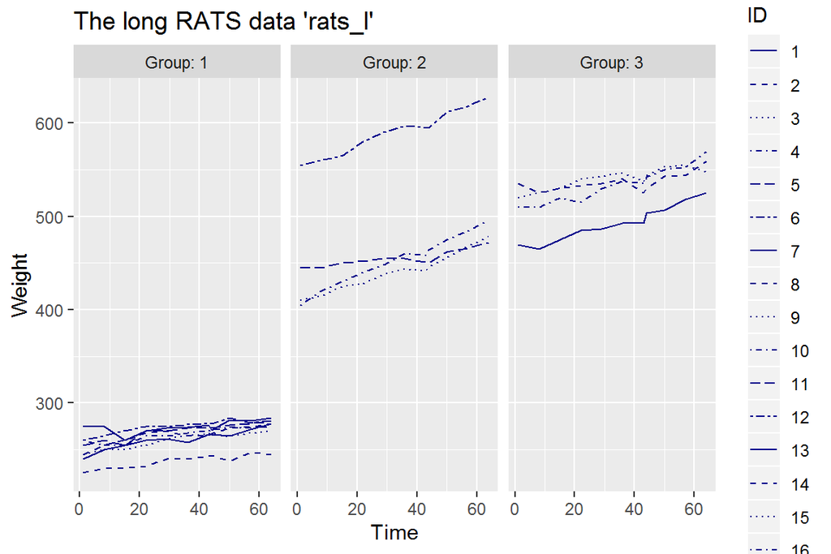

```r
ggplot(rats_l, aes(x = Time, y = Weight,linetype = ID)) +
  geom_line(color = "darkblue") +
  scale_linetype_manual(values = rep(1:6, times= 3)) +
  facet_grid(. ~ Group, labeller = label_both) +
  theme(legend.position = "right") +
  scale_y_continuous(limits = c(min(rats_l$Weight), max(rats_l$Weight))) +
 ggtitle("The long RATS data 'rats_l'")
```

Rat’s starting weights in group 2 & 3 were higher than in group 1 and the weights in group 2 & 3 increased in quite high rates. The weights in group 1 increased in a smaller rate.

### 6.2.2 Standardizing the dataset

Calculating StdWeight and added as a new variable to the ‘rats_l’

```r
rats_l <- rats_l %>%
  group_by(Time) %>%
  mutate(StdWeight = ((Weight - mean(Weight))/sd(Weight))) %>%
  ungroup()
str(rats_l)
```

```
## Classes 'tbl_df', 'tbl' and 'data.frame':    176 obs. of  6 variables:
##  $ ID       : Factor w/ 16 levels "1","2","3","4",..: 1 2 3 4 5 6 7 8 9 10 ...
##  $ Group    : Factor w/ 3 levels "1","2","3": 1 1 1 1 1 1 1 1 2 2 ...
##  $ WD       : Factor w/ 11 levels "WD1","WD15","WD22",..: 1 1 1 1 1 1 1 1 1 1 ...
##  $ Weight   : int  240 225 245 260 255 260 275 245 410 405 ...
##  $ Time     : int  1 1 1 1 1 1 1 1 1 1 ...
##  $ StdWeight: num  -1.001 -1.12 -0.961 -0.842 -0.882 ...
```

### 6.2.3 Plotting the standardised data

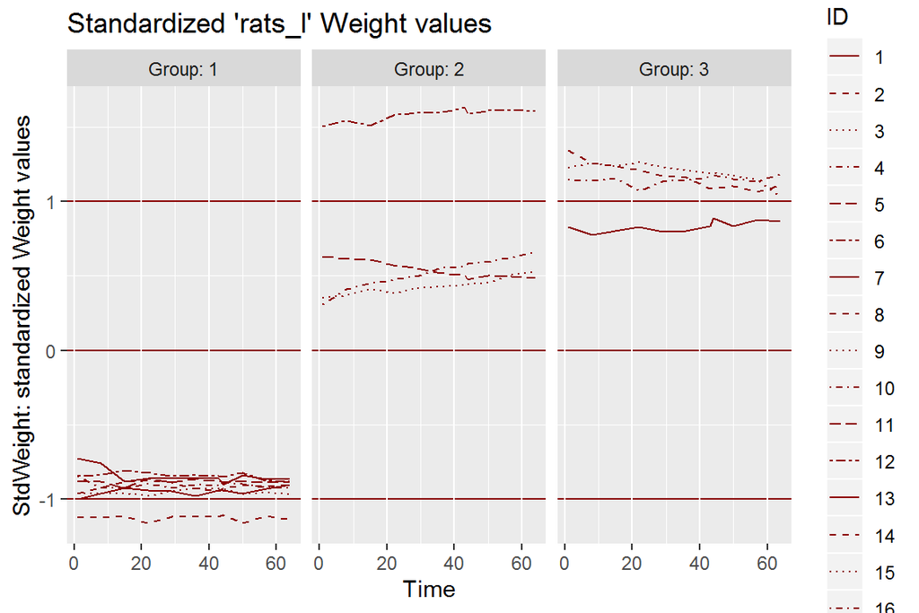

```r
ggplot(rats_l, aes(x = Time, y = StdWeight, linetype = ID)) +
  geom_line(color = "darkred") +
  scale_linetype_manual(values = rep(1:6, times=3)) +
  facet_grid(. ~ Group, labeller = label_both) +
  scale_y_continuous(name = "StdWeight: standardized Weight values") +
  ggtitle("Standardized 'rats_l' Weight values") +
  theme(panel.grid.major.y = element_line(colour = "darkred"))
```